# Ordinal Model Code

Let panel be any given DF. A theory of causality between income and depression (PHQDEP) is being formed here. for background, PHQDEP is a depression survey which ranks peoples severity of symptoms from 0 to 3. larger numbers here imply greater depressive symptoms.

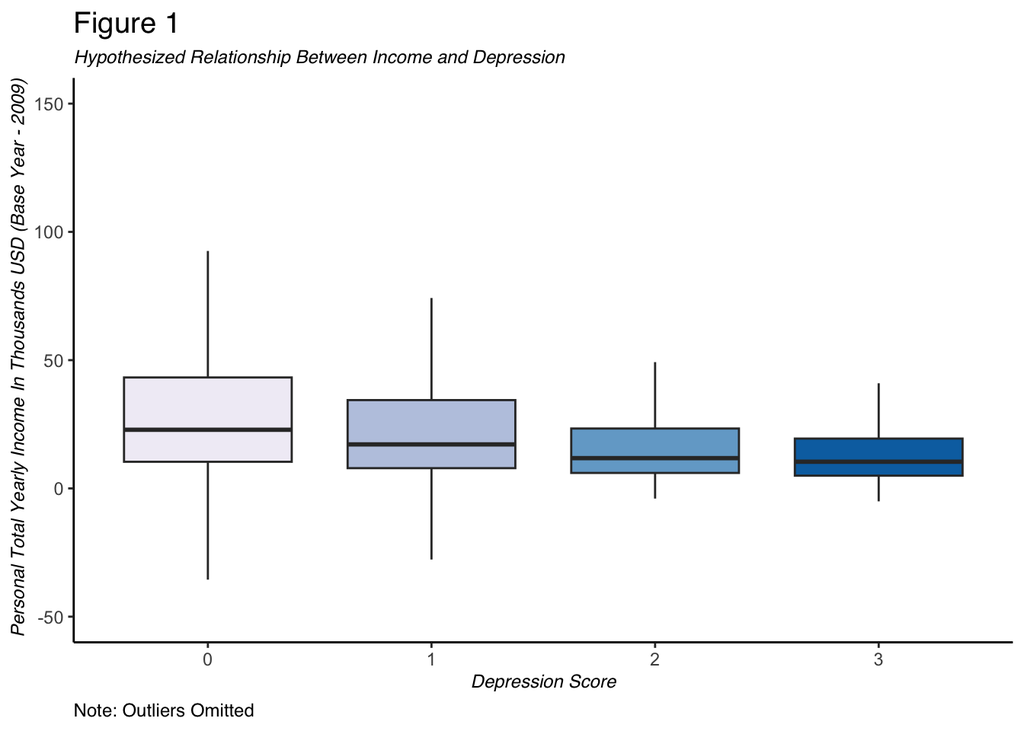

```r
#Creation of bar plots comparing income and PHQDEP scores
panel.A <- subset(panel, !is.na(panel$PHQDEP))
plot.1 <- ggplot(panel.A, aes(x = as.factor(PHQDEP), y = INCTOT, fill = as.factor(PHQDEP))) +
  geom_boxplot(size = .5,outlier.shape = NA) +
  coord_cartesian(ylim=c(-50, 150)) +
  theme_classic() +
  labs( x = "Depression Score", y = " Personal Total Yearly Income In Thousands USD (Base Year - 2009)", title = "Figure 1",subtitle = "Hypothesized Relationship Between Income and Depression",caption  = "Note: Outliers Omitted",fontface="italic") +
  theme(
       title = element_text(family = "sans",size = 12),
       axis.title.x = element_text(family = "sans",size = 9,face = "italic"),
       axis.title.y = element_text(family = "sans",size = 9,face = "italic"),
       plot.subtitle = element_text(family = "sans",size = 9,face = "italic"),
       plot.caption = element_text(family = "sans",size = 9,hjust = 0))+
  scale_fill_brewer(palette="PuBu",breaks = "PHQDEP")
plot.1
```

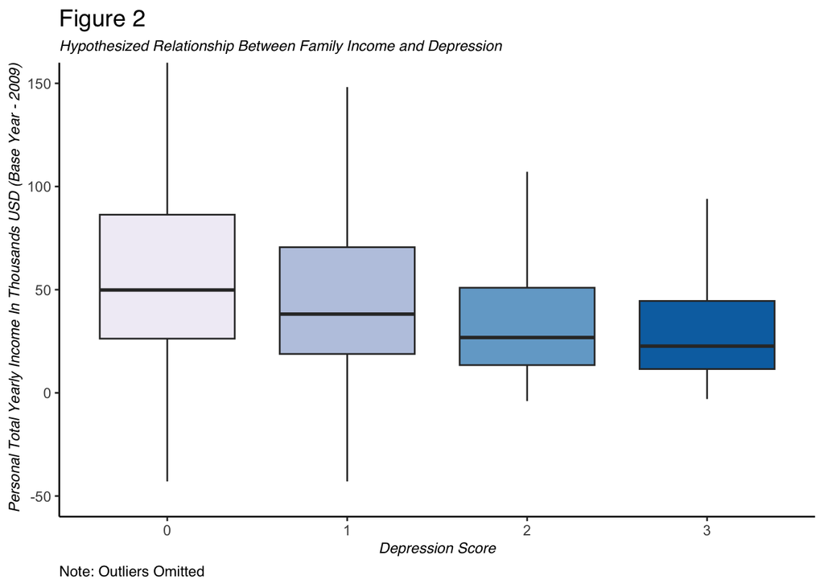

```r
plot.2 <- ggplot(panel.A, aes(x = as.factor(PHQDEP), y = FTOTINCMEPS, fill = as.factor(PHQDEP))) +
  geom_boxplot(size = .5,outlier.shape = NA) +
  coord_cartesian(ylim=c(-50, 150)) +
  theme_classic() +
  labs( x = "Depression Score", y = " Personal Total Yearly Income In Thousands USD (Base Year - 2009)", title = "Figure 2",subtitle = "Hypothesized Relationship Between Family Income and Depression",caption  = "Note: Outliers Omitted",fontface="italic") +
  theme(
    title = element_text(family = "sans",size = 12),
    axis.title.x = element_text(family = "sans",size = 9,face = "italic"),
    axis.title.y = element_text(family = "sans",size = 9,face = "italic"),
    plot.subtitle = element_text(family = "sans",size = 9,face = "italic"),
    plot.caption = element_text(family = "sans",size = 9,hjust = 0))+
  scale_fill_brewer(palette="PuBu",breaks = "PHQDEP")
plot.2
```

Formatting data into the right types, of particular importance is making response variables **ranked** factors

```r
# simply here to format data into right types
panel$YEAR <- as.factor(panel$YEAR)
panel$MEPSID <- as.factor(panel$MEPSID)
panel$DUID <- as.factor(panel$DUID)
panel$REGIONMEPS <- as.factor(panel$REGIONMEPS)
panel$SEX <- as.factor(panel$SEX)
panel$MARSTAT <- as.factor(panel$MARSTAT)
panel$HEALTH <- as.factor(panel$HEALTH)
panel$EDUC <- as.factor(panel$EDUC)
panel$AEFFORT <- factor(panel$AEFFORT,levels = c(0,1,2,3,4))
panel$AHOPELESS <- factor(panel$AHOPELESS,levels = c(0,1,2,3,4))
panel$ANERVOUS <- factor(panel$ANERVOUS,levels = c(0,1,2,3,4))
panel$ARESTLESS <- factor(panel$ARESTLESS,levels = c(0,1,2,3,4))
panel$ASAD <- factor(panel$ASAD,levels = c(0,1,2,3,4))
panel$AWORTHLESS <- factor(panel$AWORTHLESS,levels = c(0,1,2,3,4))
panel$PHQINTR <- factor(panel$PHQINTR,levels = c(0,1,2,3))
panel$PHQDEP <- factor(panel$PHQDEP,levels = c(0,1,2,3))
panel$SMOKENOW <- as.factor(panel$SMOKENOW)
panel$RACEA <- as.factor(panel$RACEA)
panel$OCCCATRD <- as.factor(panel$OCCCATRD) #Maybe dont use b/c of DF loss
panel$CANCEREV <- as.factor(panel$CANCEREV)
panel$INSULIN <- as.factor(panel$INSULIN)
panel$INTERVLANG <- as.factor(panel$INTERVLANG)
```

Here shows initial fitting of ordinal logit w/o controls

```r
panel$INCTOT <- panel$INCTOT/10 #(data is alredy divided by 100, adding another 10, because otherwise summary doesnt want to compute)
panel$INCTOT2 <- panel$INCTOT^2

panel$FTOTINCMEPS <- panel$FTOTINCMEPS/10
panel$FTOTINCMEPS2 <- panel$FTOTINCMEPS^2



QDEP.2 <- polr(PHQDEP ~ INCTOT + INCTOT2, data = panel, Hess = TRUE)
summary(QDEP.2)
```

```
## Call:
## polr(formula = PHQDEP ~ INCTOT + INCTOT2, data = panel, Hess = TRUE)
##
## Coefficients:
##             Value Std. Error t value
## INCTOT  -0.198170  0.0039627  -50.01
## INCTOT2  0.007001  0.0002579   27.14
##
## Intercepts:
##     Value    Std. Error t value
## 0|1   0.7720   0.0089    86.6574
## 1|2   2.2051   0.0114   193.5042
## 2|3   3.2236   0.0160   200.9072
##
## Residual Deviance: 264813.28
## AIC: 264823.28
## (33007 observations deleted due to missingness)
```

```r
#Between here is just me testing things
se.coef <- function(glm.output){sqrt(diag(vcov(glm.output)))}

OR <- exp(coef(QDEP.2))
Std.Error.OR_QDEP.2 <-  OR * se.coef(QDEP.2)
Std.Error.OR_QDEP.2
```

```
##       INCTOT      INCTOT2          0|1          1|2          2|3
## 0.0032503656 0.0002597468 0.0073068872 0.0114755872 0.0131608651
```

```r
stargazer((QDEP.2),apply.coef = exp,style = "qje",type = "text",p.auto = F,t.auto = F,se = list(Std.Error.OR_QDEP.2)) #w/ SE
```

```
##
## ==============================================
##                         PHQDEP
## ----------------------------------------------
## INCTOT                 0.820***
##                        (0.003)
##
## INCTOT2                1.007***
##                        (0.0003)
##
## N                      185,023
## ==============================================
## Notes:  ***Significant at the 1 percent level.
##          **Significant at the 5 percent level.
##          *Significant at the 10 percent level.
```

```r
#seeing what a summary of QDEP.2 looks like
st <- summary(QDEP.2)
p.values <- list(summary(QDEP.2)$coefficients[,3])
p.values
```

```
## [[1]]
##    INCTOT   INCTOT2       0|1       1|2       2|3
## -50.00821  27.14063  86.65737 193.50420 200.90719
```

```r
stargazer((QDEP.2),apply.coef = exp,style = "qje",type = "text",p.auto = F,t.auto = F, #try CI's
 ci = T)
```

```
##
## ==============================================
##                         PHQDEP
## ----------------------------------------------
## INCTOT                 0.820***
##                     (0.812, 0.828)
##
## INCTOT2                1.007***
##                     (1.007, 1.008)
##
## N                      185,023
## ==============================================
## Notes:  ***Significant at the 1 percent level.
##          **Significant at the 5 percent level.
##          *Significant at the 10 percent level.
```

```r
#----------------------------------

AEFT.2 <- polr(AEFFORT ~ INCTOT + INCTOT2, data = panel, Hess = TRUE)

AHOPS.2 <- polr(AHOPELESS ~ INCTOT + INCTOT2, data = panel, Hess = TRUE)

ARES.2 <- polr(ARESTLESS ~ INCTOT + INCTOT2, data = panel, Hess = TRUE)

ASAD.2 <- polr(ASAD ~ INCTOT + INCTOT2, data = panel, Hess = TRUE)

AWORS.2 <- polr(AWORTHLESS ~ INCTOT + INCTOT2, data = panel, Hess = TRUE)

QINTR.2 <- polr(PHQINTR ~ INCTOT + INCTOT2, data = panel, Hess = TRUE)

aicVals <- AIC(QDEP.2)
aicVals <- c(AIC(AEFT.2),aicVals)
aicVals <- c(AIC(AHOPS.2),aicVals)
aicVals <- c(AIC(ARES.2),aicVals)
aicVals <- c(AIC(ASAD.2),aicVals)
aicVals <- c(AIC(AWORS.2),aicVals)
aicVals <- c(AIC(QINTR.2),aicVals)

print(aicVals)
```

```
## [1] 277924.4 238005.1 270840.2 425325.7 299840.9 400227.6 264823.3
```

```r
print('QDEP.2  AEFT.2  AHOPS.2  ARES.2  ASAD.2  AWORS.2  QINTR.2')
```

```
## [1] "QDEP.2  AEFT.2  AHOPS.2  ARES.2  ASAD.2  AWORS.2  QINTR.2"
```

```r
stargazer(QDEP.2,QINTR.2,AEFT.2,AHOPS.2,ARES.2,ASAD.2,AWORS.2,apply.coef = exp,style = "qje",ci = T,p.auto = F)
```

```
##
## % Table created by stargazer v.5.2.3 by Marek Hlavac, Social Policy Institute. E-mail: marek.hlavac at gmail.com
## % Date and time: Wed, Nov 29, 2023 - 23:10:10
## \begin{table}[!htbp] \centering
##   \caption{}
##   \label{}
## \begin{tabular}{@{\extracolsep{5pt}}lccccccc}
## \\[-1.8ex]\hline
## \hline \\[-1.8ex]
## \\[-1.8ex] & PHQDEP & PHQINTR & AEFFORT & AHOPELESS & ARESTLESS & ASAD & AWORTHLESS \\
## \\[-1.8ex] & (1) & (2) & (3) & (4) & (5) & (6) & (7)\\
## \hline \\[-1.8ex]
##  INCTOT & 0.820$^{***}$ & 0.807$^{***}$ & 0.865$^{***}$ & 0.806$^{***}$ & 0.907$^{***}$ & 0.789$^{***}$ & 0.798$^{***}$ \\
##   & (0.812, 0.828) & (0.800, 0.815) & (0.858, 0.871) & (0.798, 0.813) & (0.901, 0.913) & (0.781, 0.797) & (0.789, 0.806) \\
##   & & & & & & & \\
##  INCTOT2 & 1.007$^{***}$ & 1.007$^{***}$ & 1.005$^{***}$ & 1.007$^{***}$ & 1.004$^{***}$ & 1.008$^{***}$ & 1.008$^{***}$ \\
##   & (1.007, 1.008) & (1.007, 1.008) & (1.005, 1.006) & (1.007, 1.008) & (1.003, 1.004) & (1.008, 1.009) & (1.007, 1.008) \\
##   & & & & & & & \\
## \textit{N} & 185,023 & 185,423 & 184,665 & 184,900 & 184,688 & 184,868 & 184,693 \\
## \hline
## \hline \\[-1.8ex]
## \textit{Notes:} & \multicolumn{7}{r}{$^{***}$Significant at the 1 percent level.} \\
##  & \multicolumn{7}{r}{$^{**}$Significant at the 5 percent level.} \\
##  & \multicolumn{7}{r}{$^{*}$Significant at the 10 percent level.} \\
## \end{tabular}
## \end{table}
```

```r
stargazer(QDEP.2,QINTR.2,AEFT.2,AHOPS.2,ARES.2,ASAD.2,AWORS.2,apply.coef = exp,style = "qje", type = 'text', ci = T, p.auto = F)
```

```
##
## ================================================================================================================
##             PHQDEP        PHQINTR        AEFFORT       AHOPELESS      ARESTLESS         ASAD        AWORTHLESS
##              (1)            (2)            (3)            (4)            (5)            (6)            (7)
## ----------------------------------------------------------------------------------------------------------------
## INCTOT     0.820***       0.807***       0.865***       0.806***       0.907***       0.789***       0.798***
##         (0.812, 0.828) (0.800, 0.815) (0.858, 0.871) (0.798, 0.813) (0.901, 0.913) (0.781, 0.797) (0.789, 0.806)
##
## INCTOT2    1.007***       1.007***       1.005***       1.007***       1.004***       1.008***       1.008***
##         (1.007, 1.008) (1.007, 1.008) (1.005, 1.006) (1.007, 1.008) (1.003, 1.004) (1.008, 1.009) (1.007, 1.008)
##
## N          185,023        185,423        184,665        184,900        184,688        184,868        184,693
## ================================================================================================================
## Notes:                                                                    ***Significant at the 1 percent level.
##                                                                            **Significant at the 5 percent level.
##                                                                            *Significant at the 10 percent level.
```

Here shows initial fitting of the ordinal logit with controls .

```r
#Fitting of first models, no instruments are used here


model.1 <- polr(PHQDEP ~ INCTOT + INCTOT2, data = panel, Hess = TRUE)
summary(model.1)
```

```
## Call:
## polr(formula = PHQDEP ~ INCTOT + INCTOT2, data = panel, Hess = TRUE)
##
## Coefficients:
##             Value Std. Error t value
## INCTOT  -0.198170  0.0039627  -50.01
## INCTOT2  0.007001  0.0002579   27.14
##
## Intercepts:
##     Value    Std. Error t value
## 0|1   0.7720   0.0089    86.6574
## 1|2   2.2051   0.0114   193.5042
## 2|3   3.2236   0.0160   200.9072
##
## Residual Deviance: 264813.28
## AIC: 264823.28
## (33007 observations deleted due to missingness)
```

```r
model.2 <- polr(PHQDEP ~ INCTOT + INCTOT2+ FTOTINCMEPS + YEAR + REGIONMEPS +SEX + MARSTAT, data = panel, Hess = TRUE)
summary(model.2)
```

```
## Call:
## polr(formula = PHQDEP ~ INCTOT + INCTOT2 + FTOTINCMEPS + YEAR +
##     REGIONMEPS + SEX + MARSTAT, data = panel, Hess = TRUE)
##
## Coefficients:
##                 Value Std. Error t value
## INCTOT      -0.149810  0.0044149 -33.933
## INCTOT2      0.007469  0.0002628  28.423
## FTOTINCMEPS -0.044451  0.0017123 -25.959
## YEAR2011     0.005884  0.0228065   0.258
## YEAR2012    -0.024392  0.0222675  -1.095
## YEAR2013    -0.141168  0.0230420  -6.127
## YEAR2014    -0.195618  0.0238516  -8.201
## YEAR2015    -0.190683  0.0236145  -8.075
## YEAR2016    -0.218453  0.0238857  -9.146
## YEAR2017    -0.249758  0.0242883 -10.283
## YEAR2018    -0.184387  0.0245181  -7.520
## REGIONMEPS1  0.406385  0.0127033  31.991
## REGIONMEPS2  0.478186  0.0115003  41.580
## REGIONMEPS3  0.363877  0.0092624  39.285
## REGIONMEPS4  0.386549  0.0105291  36.713
## SEX2         0.239959  0.0116217  20.648
## MARSTAT20    0.338548  0.0224647  15.070
## MARSTAT30    0.478534  0.0175101  27.329
## MARSTAT40    0.570631  0.0297960  19.151
## MARSTAT50    0.086576  0.0135168   6.405
##
## Intercepts:
##     Value    Std. Error t value
## 0|1   1.2026   0.0173    69.6409
## 1|2   2.6543   0.0188   141.3746
## 2|3   3.6793   0.0219   167.7571
##
## Residual Deviance: 261453.79
## AIC: 261499.79
## (33008 observations deleted due to missingness)
```

```r
QDEP.3 <- polr(PHQDEP ~ INCTOT + INCTOT2 + FTOTINCMEPS + FTOTINCMEPS2 + YEAR + REGIONMEPS +SEX + MARSTAT + HEALTH +
                  EDUC + SMOKENOW + RACEA + CANCEREV + INTERVLANG + FAMSIZE +ANERVOUS,
                  data = panel, Hess = TRUE)
pander(QDEP.3)
```

Call: polr(formula = PHQDEP ~ INCTOT + INCTOT2 + FTOTINCMEPS + FTOTINCMEPS2 + YEAR + REGIONMEPS + SEX + MARSTAT + HEALTH + EDUC + SMOKENOW + RACEA + CANCEREV + INTERVLANG + FAMSIZE + ANERVOUS, data = panel, Hess = TRUE)

Coefficients (continued below)

| INCTOT | INCTOT2 | FTOTINCMEPS | FTOTINCMEPS2 | YEAR2011 | YEAR2012 |
| --- | --- | --- | --- | --- | --- |
| -0.05808 | 0.002702 | -0.03607 | 0.0006481 | -0.005743 | -0.02557 |

Table continues below

| YEAR2013 | YEAR2014 | YEAR2015 | YEAR2016 | YEAR2017 | REGIONMEPS1 |
| --- | --- | --- | --- | --- | --- |
| -0.1215 | -0.1155 | -0.1517 | -0.1495 | -0.1532 | -1.108 |

Table continues below

| REGIONMEPS2 | REGIONMEPS3 | REGIONMEPS4 | SEX2 | MARSTAT20 | MARSTAT30 |
| --- | --- | --- | --- | --- | --- |
| -1.141 | -1.119 | -1.119 | 0.1184 | 0.07847 | 0.2359 |

Table continues below

| MARSTAT40 | MARSTAT50 | HEALTH2 | HEALTH3 | HEALTH4 | HEALTH5 | EDUC101 |
| --- | --- | --- | --- | --- | --- | --- |
| 0.3175 | 0.1816 | 0.4423 | 0.9614 | 1.62 | 2.34 | -0.005218 |

Table continues below

| EDUC102 | EDUC104 | EDUC105 | EDUC106 | EDUC107 | EDUC108 | EDUC109 | EDUC110 |
| --- | --- | --- | --- | --- | --- | --- | --- |
| 0.09792 | 0.2924 | 0.2084 | -0.1627 | 0.1135 | 0.03967 | -0.09992 | 0.06146 |

Table continues below

| EDUC111 | EDUC112 | EDUC113 | EDUC114 | EDUC115 | EDUC116 | EDUC200 |
| --- | --- | --- | --- | --- | --- | --- |
| 0.05779 | -0.01009 | -0.02376 | 0.003444 | 0.07047 | 0.1526 | 1.105 |

Table continues below

| EDUC201 | EDUC202 | EDUC301 | EDUC302 | EDUC303 | EDUC400 | EDUC500 | EDUC501 |
| --- | --- | --- | --- | --- | --- | --- | --- |
| 0.01492 | 0.157 | 0.02516 | 0.06167 | 0.07879 | 0.09047 | 0.1411 | 0.05238 |

Table continues below

| EDUC502 | EDUC503 | EDUC504 | SMOKENOW2 | RACEA200 | RACEA310 | RACEA410 |
| --- | --- | --- | --- | --- | --- | --- |
| 0.2712 | 0.2038 | 0.07166 | 0.347 | -0.04806 | 0.06911 | 0.01379 |

Table continues below

| RACEA420 | RACEA600 | CANCEREV2 | INTERVLANG2 | INTERVLANG3 | INTERVLANG4 |
| --- | --- | --- | --- | --- | --- |
| -0.04357 | 0.06651 | -0.02261 | -0.2424 | -0.1279 | -0.0812 |

| FAMSIZE | ANERVOUS1 | ANERVOUS2 | ANERVOUS3 | ANERVOUS4 |
| --- | --- | --- | --- | --- |
| 0.01373 | 1.449 | 2.686 | 3.994 | 4.812 |

Intercepts

| 0\|1 | 1\|2 | 2\|3 |
| --- | --- | --- |
| 2.126 | 4.237 | 5.608 |

Residual Deviance: 171985.27 AIC: 172123.27 (58042 observations deleted due to missingness)

```r
AEFT.3 <-polr(AEFFORT ~ INCTOT + INCTOT2 + FTOTINCMEPS + FTOTINCMEPS2 + YEAR + REGIONMEPS +SEX + MARSTAT + HEALTH +
                           EDUC + SMOKENOW + RACEA + CANCEREV + INTERVLANG + FAMSIZE + ANERVOUS,
                          data = panel, Hess = TRUE)
AHOPS.3 <-polr(AHOPELESS ~ INCTOT + INCTOT2 + FTOTINCMEPS + FTOTINCMEPS2 + YEAR + REGIONMEPS +SEX + MARSTAT + HEALTH +
                         EDUC + SMOKENOW + RACEA + CANCEREV + INTERVLANG + FAMSIZE + ANERVOUS,
                       data = panel, Hess = TRUE)
ARES.3 <-polr(ARESTLESS ~ INCTOT + INCTOT2 + FTOTINCMEPS + FTOTINCMEPS2 + YEAR + REGIONMEPS +SEX + MARSTAT + HEALTH +
                         EDUC + SMOKENOW + RACEA + CANCEREV + INTERVLANG + FAMSIZE + ANERVOUS,
                       data = panel, Hess = TRUE)
ASAD.3 <-polr(ASAD ~ INCTOT + INCTOT2 + FTOTINCMEPS + FTOTINCMEPS2 + YEAR + REGIONMEPS +SEX + MARSTAT + HEALTH +
                         EDUC + SMOKENOW + RACEA + CANCEREV + INTERVLANG + FAMSIZE + ANERVOUS,
                       data = panel, Hess = TRUE)
AWORS.3 <-polr(AWORTHLESS ~ INCTOT + INCTOT2 + FTOTINCMEPS + FTOTINCMEPS2 + YEAR + REGIONMEPS +SEX + MARSTAT + HEALTH +
                         EDUC + SMOKENOW + RACEA + CANCEREV + INTERVLANG + FAMSIZE + ANERVOUS,
                       data = panel, Hess = TRUE)
QINTR.3 <-polr(PHQINTR ~ INCTOT + INCTOT2 + FTOTINCMEPS + FTOTINCMEPS2 + YEAR + REGIONMEPS +SEX + MARSTAT + HEALTH +
                         EDUC + SMOKENOW + RACEA + CANCEREV + INTERVLANG + FAMSIZE + ANERVOUS,
                       data = panel, Hess = TRUE)
aicVals <- AIC(QDEP.3)
aicVals <- c(AIC(AEFT.3),aicVals)
aicVals <- c(AIC(AHOPS.3),aicVals)
aicVals <- c(AIC(ARES.3),aicVals)
aicVals <- c(AIC(ASAD.3),aicVals)
aicVals <- c(AIC(AWORS.3),aicVals)
aicVals <- c(AIC(QINTR.3),aicVals)

print('QDEP.3  AEFT.3  AHOPS.3  ARES.3  ASAD.3  AWORS.3  QINTR.3')
```

```
## [1] "QDEP.3  AEFT.3  AHOPS.3  ARES.3  ASAD.3  AWORS.3  QINTR.3"
```

```r
print(aicVals)
```

```
## [1] 186453.8 160816.2 180125.7 281515.6 193936.0 279436.3 172123.3
```

```r
stargazer(QDEP.3 ,QINTR.3,AEFT.3 ,AHOPS.3,ARES.3,ASAD.3,AWORS.3, apply.coef = exp,style = "qje",ci=T, p.auto= F)
```

```
##
## % Table created by stargazer v.5.2.3 by Marek Hlavac, Social Policy Institute. E-mail: marek.hlavac at gmail.com
## % Date and time: Wed, Nov 29, 2023 - 23:15:05
## \begin{table}[!htbp] \centering
##   \caption{}
##   \label{}
## \begin{tabular}{@{\extracolsep{5pt}}lccccccc}
## \\[-1.8ex]\hline
## \hline \\[-1.8ex]
## \\[-1.8ex] & PHQDEP & PHQINTR & AEFFORT & AHOPELESS & ARESTLESS & ASAD & AWORTHLESS \\
## \\[-1.8ex] & (1) & (2) & (3) & (4) & (5) & (6) & (7)\\
## \hline \\[-1.8ex]
##  INCTOT & 0.944$^{***}$ & 0.933$^{***}$ & 0.959$^{***}$ & 0.946$^{***}$ & 0.988$^{**}$ & 0.944$^{***}$ & 0.914$^{***}$ \\
##   & (0.931, 0.956) & (0.921, 0.945) & (0.949, 0.969) & (0.934, 0.958) & (0.979, 0.998) & (0.931, 0.956) & (0.900, 0.928) \\
##   & & & & & & & \\
##  INCTOT2 & 1.003$^{***}$ & 1.003$^{***}$ & 1.002$^{***}$ & 1.002$^{***}$ & 1.001$^{***}$ & 1.002$^{***}$ & 1.003$^{***}$ \\
##   & (1.002, 1.003) & (1.002, 1.004) & (1.001, 1.003) & (1.001, 1.003) & (1.000, 1.001) & (1.002, 1.003) & (1.003, 1.004) \\
##   & & & & & & & \\
##  FTOTINCMEPS & 0.965$^{***}$ & 0.974$^{***}$ & 0.968$^{***}$ & 0.956$^{***}$ & 0.981$^{***}$ & 0.962$^{***}$ & 0.967$^{***}$ \\
##   & (0.957, 0.972) & (0.966, 0.981) & (0.961, 0.974) & (0.948, 0.964) & (0.975, 0.987) & (0.954, 0.970) & (0.958, 0.975) \\
##   & & & & & & & \\
##  FTOTINCMEPS2 & 1.001$^{***}$ & 1.000$^{***}$ & 1.001$^{***}$ & 1.001$^{***}$ & 1.001$^{***}$ & 1.001$^{***}$ & 1.001$^{***}$ \\
##   & (1.000, 1.001) & (1.000, 1.001) & (1.000, 1.001) & (1.001, 1.001) & (1.000, 1.001) & (1.000, 1.001) & (1.000, 1.001) \\
##   & & & & & & & \\
##  YEAR2011 & 0.994 & 0.983 & 0.980 & 0.977 & 1.000 & 0.977 & 0.881$^{***}$ \\
##   & (0.942, 1.046) & (0.932, 1.033) & (0.938, 1.023) & (0.926, 1.027) & (0.959, 1.041) & (0.925, 1.029) & (0.825, 0.937) \\
##   & & & & & & & \\
##  YEAR2012 & 0.975 & 0.966 & 0.979 & 0.984 & 0.985 & 0.936$^{**}$ & 0.891$^{***}$ \\
##   & (0.924, 1.026) & (0.917, 1.016) & (0.937, 1.021) & (0.935, 1.033) & (0.945, 1.026) & (0.885, 0.988) & (0.836, 0.946) \\
##   & & & & & & & \\
##  YEAR2013 & 0.886$^{***}$ & 0.929$^{**}$ & 0.907$^{***}$ & 0.932$^{**}$ & 0.941$^{***}$ & 0.887$^{***}$ & 0.813$^{***}$ \\
##   & (0.827, 0.944) & (0.873, 0.985) & (0.860, 0.954) & (0.875, 0.988) & (0.897, 0.985) & (0.828, 0.946) & (0.750, 0.877) \\
##   & & & & & & & \\
##  YEAR2014 & 0.891$^{***}$ & 0.903$^{***}$ & 0.866$^{***}$ & 0.902$^{***}$ & 0.866$^{***}$ & 0.888$^{***}$ & 0.790$^{***}$ \\
##   & (0.832, 0.950) & (0.846, 0.961) & (0.818, 0.913) & (0.845, 0.960) & (0.820, 0.912) & (0.828, 0.947) & (0.725, 0.854) \\
##   & & & & & & & \\
##  YEAR2015 & 0.859$^{***}$ & 0.910$^{***}$ & 0.871$^{***}$ & 0.865$^{***}$ & 0.863$^{***}$ & 0.862$^{***}$ & 0.784$^{***}$ \\
##   & (0.804, 0.914) & (0.856, 0.963) & (0.827, 0.916) & (0.812, 0.918) & (0.820, 0.906) & (0.806, 0.918) & (0.725, 0.844) \\
##   & & & & & & & \\
##  YEAR2016 & 0.861$^{***}$ & 0.867$^{***}$ & 0.820$^{***}$ & 0.830$^{***}$ & 0.822$^{***}$ & 0.834$^{***}$ & 0.754$^{***}$ \\
```

[output cut: 163 more lines]

```
##   & & & & & & & \\
##  ANERVOUS3 & 54.263$^{***}$ & 31.320$^{***}$ & 34.214$^{***}$ & 103.061$^{***}$ & 118.711$^{***}$ & 59.990$^{***}$ & 49.002$^{***}$ \\
##   & (54.203, 54.323) & (31.262, 31.378) & (34.160, 34.269) & (102.999, 103.123) & (118.651, 118.770) & (59.929, 60.051) & (48.939, 49.066) \\
##   & & & & & & & \\
##  ANERVOUS4 & 122.996$^{***}$ & 66.373$^{***}$ & 93.341$^{***}$ & 426.091$^{***}$ & 651.639$^{***}$ & 212.990$^{***}$ & 141.750$^{***}$ \\
##   & (122.901, 123.091) & (66.281, 66.466) & (93.250, 93.433) & (425.989, 426.193) & (651.537, 651.740) & (212.891, 213.089) & (141.651, 141.848) \\
##   & & & & & & & \\
## \textit{N} & 159,988 & 160,189 & 159,867 & 160,163 & 159,897 & 160,067 & 159,949 \\
## \hline
## \hline \\[-1.8ex]
## \textit{Notes:} & \multicolumn{7}{r}{$^{***}$Significant at the 1 percent level.} \\
##  & \multicolumn{7}{r}{$^{**}$Significant at the 5 percent level.} \\
##  & \multicolumn{7}{r}{$^{*}$Significant at the 10 percent level.} \\
## \end{tabular}
## \end{table}
```

```r
keep.1 <- c("INCTOT","FTOTINCMEPS","SEX2","MARSTAT30","HEALTH5","EDUC400","SMOKENOW2","RACE200","CANCEREV2","INVERVLANG2","ANERVOUS1","INCTOT2","FTOTINCMEPS2")
stargazer(QDEP.3 ,QINTR.3,AEFT.3 ,AHOPS.3,ARES.3,ASAD.3,AWORS.3, keep = keep.1,apply.coef = exp,style = "qje",ci = T, p.auto = F)
```

```
##
## % Table created by stargazer v.5.2.3 by Marek Hlavac, Social Policy Institute. E-mail: marek.hlavac at gmail.com
## % Date and time: Wed, Nov 29, 2023 - 23:15:09
## \begin{table}[!htbp] \centering
##   \caption{}
##   \label{}
## \begin{tabular}{@{\extracolsep{5pt}}lccccccc}
## \\[-1.8ex]\hline
## \hline \\[-1.8ex]
## \\[-1.8ex] & PHQDEP & PHQINTR & AEFFORT & AHOPELESS & ARESTLESS & ASAD & AWORTHLESS \\
## \\[-1.8ex] & (1) & (2) & (3) & (4) & (5) & (6) & (7)\\
## \hline \\[-1.8ex]
##  INCTOT & 0.944$^{***}$ & 0.933$^{***}$ & 0.959$^{***}$ & 0.946$^{***}$ & 0.988$^{**}$ & 0.944$^{***}$ & 0.914$^{***}$ \\
##   & (0.931, 0.956) & (0.921, 0.945) & (0.949, 0.969) & (0.934, 0.958) & (0.979, 0.998) & (0.931, 0.956) & (0.900, 0.928) \\
##   & & & & & & & \\
##  INCTOT2 & 1.003$^{***}$ & 1.003$^{***}$ & 1.002$^{***}$ & 1.002$^{***}$ & 1.001$^{***}$ & 1.002$^{***}$ & 1.003$^{***}$ \\
##   & (1.002, 1.003) & (1.002, 1.004) & (1.001, 1.003) & (1.001, 1.003) & (1.000, 1.001) & (1.002, 1.003) & (1.003, 1.004) \\
##   & & & & & & & \\
##  FTOTINCMEPS & 0.965$^{***}$ & 0.974$^{***}$ & 0.968$^{***}$ & 0.956$^{***}$ & 0.981$^{***}$ & 0.962$^{***}$ & 0.967$^{***}$ \\
##   & (0.957, 0.972) & (0.966, 0.981) & (0.961, 0.974) & (0.948, 0.964) & (0.975, 0.987) & (0.954, 0.970) & (0.958, 0.975) \\
##   & & & & & & & \\
##  FTOTINCMEPS2 & 1.001$^{***}$ & 1.000$^{***}$ & 1.001$^{***}$ & 1.001$^{***}$ & 1.001$^{***}$ & 1.001$^{***}$ & 1.001$^{***}$ \\
##   & (1.000, 1.001) & (1.000, 1.001) & (1.000, 1.001) & (1.001, 1.001) & (1.000, 1.001) & (1.000, 1.001) & (1.000, 1.001) \\
##   & & & & & & & \\
##  SEX2 & 1.126$^{***}$ & 0.963$^{***}$ & 0.966$^{***}$ & 0.949$^{***}$ & 0.926$^{***}$ & 1.107$^{***}$ & 0.890$^{***}$ \\
##   & (1.097, 1.154) & (0.936, 0.990) & (0.943, 0.988) & (0.921, 0.976) & (0.904, 0.948) & (1.078, 1.135) & (0.859, 0.921) \\
##   & & & & & & & \\
##  MARSTAT30 & 1.266$^{***}$ & 1.241$^{***}$ & 1.153$^{***}$ & 1.253$^{***}$ & 1.093$^{***}$ & 1.302$^{***}$ & 1.204$^{***}$ \\
##   & (1.222, 1.310) & (1.199, 1.284) & (1.117, 1.189) & (1.210, 1.296) & (1.057, 1.128) & (1.258, 1.347) & (1.155, 1.252) \\
##   & & & & & & & \\
##  HEALTH5 & 10.378$^{***}$ & 12.559$^{***}$ & 11.745$^{***}$ & 8.031$^{***}$ & 5.405$^{***}$ & 7.427$^{***}$ & 8.280$^{***}$ \\
##   & (10.300, 10.455) & (12.482, 12.635) & (11.677, 11.813) & (7.955, 8.107) & (5.337, 5.472) & (7.349, 7.504) & (8.197, 8.363) \\
##   & & & & & & & \\
##  EDUC400 & 1.095 & 0.984 & 1.137$^{**}$ & 0.945 & 1.215$^{***}$ & 0.752$^{***}$ & 0.904 \\
##   & (0.959, 1.230) & (0.854, 1.114) & (1.024, 1.250) & (0.823, 1.067) & (1.169, 1.261) & (0.625, 0.879) & (0.761, 1.047) \\
##   & & & & & & & \\
##  SMOKENOW2 & 1.415$^{***}$ & 1.338$^{***}$ & 1.214$^{***}$ & 1.322$^{***}$ & 1.379$^{***}$ & 1.377$^{***}$ & 1.319$^{***}$ \\
##   & (1.380, 1.449) & (1.304, 1.371) & (1.184, 1.243) & (1.288, 1.356) & (1.350, 1.407) & (1.342, 1.412) & (1.282, 1.356) \\
##   & & & & & & & \\
##  CANCEREV2 & 0.978 & 1.119$^{***}$ & 1.151$^{***}$ & 0.921$^{***}$ & 0.967$^{*}$ & 0.924$^{***}$ & 0.961 \\
##   & (0.932, 1.023) & (1.075, 1.162) & (1.114, 1.188) & (0.875, 0.967) & (0.930, 1.004) & (0.876, 0.972) & (0.911, 1.011) \\
##   & & & & & & & \\
##  ANERVOUS1 & 4.259$^{***}$ & 3.617$^{***}$ & 4.420$^{***}$ & 6.167$^{***}$ & 6.413$^{***}$ & 4.699$^{***}$ & 5.004$^{***}$ \\
##   & (4.223, 4.294) & (3.584, 3.651) & (4.393, 4.446) & (6.132, 6.203) & (6.388, 6.438) & (4.662, 4.736) & (4.960, 5.047) \\
##   & & & & & & & \\
## \textit{N} & 159,988 & 160,189 & 159,867 & 160,163 & 159,897 & 160,067 & 159,949 \\
## \hline
## \hline \\[-1.8ex]
## \textit{Notes:} & \multicolumn{7}{r}{$^{***}$Significant at the 1 percent level.} \\
##  & \multicolumn{7}{r}{$^{**}$Significant at the 5 percent level.} \\
##  & \multicolumn{7}{r}{$^{*}$Significant at the 10 percent level.} \\
## \end{tabular}
## \end{table}
```

```r
stargazer(QDEP.3 ,QINTR.3,AEFT.3 ,AHOPS.3,ARES.3,ASAD.3,AWORS.3, keep = keep.1,apply.coef = exp,style = "qje",ci = T, p.auto = F,type= "text")
```

```
##
## ===========================================================================================================================
##                   PHQDEP          PHQINTR          AEFFORT        AHOPELESS      ARESTLESS         ASAD        AWORTHLESS
##                    (1)              (2)              (3)             (4)            (5)            (6)            (7)
## ---------------------------------------------------------------------------------------------------------------------------
## INCTOT           0.944***         0.933***         0.959***        0.946***       0.988**        0.944***       0.914***
##               (0.931, 0.956)   (0.921, 0.945)   (0.949, 0.969)  (0.934, 0.958) (0.979, 0.998) (0.931, 0.956) (0.900, 0.928)
##
## INCTOT2          1.003***         1.003***         1.002***        1.002***       1.001***       1.002***       1.003***
##               (1.002, 1.003)   (1.002, 1.004)   (1.001, 1.003)  (1.001, 1.003) (1.000, 1.001) (1.002, 1.003) (1.003, 1.004)
##
## FTOTINCMEPS      0.965***         0.974***         0.968***        0.956***       0.981***       0.962***       0.967***
##               (0.957, 0.972)   (0.966, 0.981)   (0.961, 0.974)  (0.948, 0.964) (0.975, 0.987) (0.954, 0.970) (0.958, 0.975)
##
## FTOTINCMEPS2     1.001***         1.000***         1.001***        1.001***       1.001***       1.001***       1.001***
##               (1.000, 1.001)   (1.000, 1.001)   (1.000, 1.001)  (1.001, 1.001) (1.000, 1.001) (1.000, 1.001) (1.000, 1.001)
##
## SEX2             1.126***         0.963***         0.966***        0.949***       0.926***       1.107***       0.890***
##               (1.097, 1.154)   (0.936, 0.990)   (0.943, 0.988)  (0.921, 0.976) (0.904, 0.948) (1.078, 1.135) (0.859, 0.921)
##
## MARSTAT30        1.266***         1.241***         1.153***        1.253***       1.093***       1.302***       1.204***
##               (1.222, 1.310)   (1.199, 1.284)   (1.117, 1.189)  (1.210, 1.296) (1.057, 1.128) (1.258, 1.347) (1.155, 1.252)
##
## HEALTH5         10.378***        12.559***        11.745***        8.031***       5.405***       7.427***       8.280***
##              (10.300, 10.455) (12.482, 12.635) (11.677, 11.813) (7.955, 8.107) (5.337, 5.472) (7.349, 7.504) (8.197, 8.363)
##
## EDUC400           1.095            0.984           1.137**          0.945         1.215***       0.752***        0.904
##               (0.959, 1.230)   (0.854, 1.114)   (1.024, 1.250)  (0.823, 1.067) (1.169, 1.261) (0.625, 0.879) (0.761, 1.047)
##
## SMOKENOW2        1.415***         1.338***         1.214***        1.322***       1.379***       1.377***       1.319***
##               (1.380, 1.449)   (1.304, 1.371)   (1.184, 1.243)  (1.288, 1.356) (1.350, 1.407) (1.342, 1.412) (1.282, 1.356)
##
## CANCEREV2         0.978           1.119***         1.151***        0.921***        0.967*        0.924***        0.961
##               (0.932, 1.023)   (1.075, 1.162)   (1.114, 1.188)  (0.875, 0.967) (0.930, 1.004) (0.876, 0.972) (0.911, 1.011)
##
## ANERVOUS1        4.259***         3.617***         4.420***        6.167***       6.413***       4.699***       5.004***
##               (4.223, 4.294)   (3.584, 3.651)   (4.393, 4.446)  (6.132, 6.203) (6.388, 6.438) (4.662, 4.736) (4.960, 5.047)
##
## N                159,988          160,189          159,867         160,163        159,897        160,067        159,949
## ===========================================================================================================================
## Notes:                                                                               ***Significant at the 1 percent level.
##                                                                                       **Significant at the 5 percent level.
##                                                                                       *Significant at the 10 percent level.
```

```r
QDEP.3 <- polr(PHQDEP ~ INCTOT +  FTOTINCMEPS + YEAR + REGIONMEPS +SEX + MARSTAT + HEALTH +
                  EDUC + SMOKENOW + RACEA + CANCEREV + INTERVLANG + FAMSIZE +ANERVOUS,
                  data = panel, Hess = TRUE)
AEFT.3 <-polr(AEFFORT ~ INCTOT + FTOTINCMEPS + YEAR + REGIONMEPS +SEX + MARSTAT + HEALTH +
                           EDUC + SMOKENOW + RACEA + CANCEREV + INTERVLANG + FAMSIZE + ANERVOUS,
                          data = panel, Hess = TRUE)
AHOPS.3 <-polr(AHOPELESS ~ INCTOT + FTOTINCMEPS + YEAR + REGIONMEPS +SEX + MARSTAT + HEALTH +
                         EDUC + SMOKENOW + RACEA + CANCEREV + INTERVLANG + FAMSIZE + ANERVOUS,
                       data = panel, Hess = TRUE)
ARES.3 <-polr(ARESTLESS ~ INCTOT + FTOTINCMEPS + YEAR + REGIONMEPS +SEX + MARSTAT + HEALTH +
                         EDUC + SMOKENOW + RACEA + CANCEREV + INTERVLANG + FAMSIZE + ANERVOUS,
                       data = panel, Hess = TRUE)
ASAD.3 <-polr(ASAD ~ INCTOT + FTOTINCMEPS + YEAR + REGIONMEPS +SEX + MARSTAT + HEALTH +
                         EDUC + SMOKENOW + RACEA + CANCEREV + INTERVLANG + FAMSIZE + ANERVOUS,
                       data = panel, Hess = TRUE)
AWORS.3 <-polr(AWORTHLESS ~ INCTOT + FTOTINCMEPS + YEAR + REGIONMEPS +SEX + MARSTAT + HEALTH +
                         EDUC + SMOKENOW + RACEA + CANCEREV + INTERVLANG + FAMSIZE + ANERVOUS,
                       data = panel, Hess = TRUE)
QINTR.3 <-polr(PHQINTR ~ INCTOT + FTOTINCMEPS + YEAR + REGIONMEPS +SEX + MARSTAT + HEALTH +
                         EDUC + SMOKENOW + RACEA + CANCEREV + INTERVLANG + FAMSIZE + ANERVOUS,
                       data = panel, Hess = TRUE)
aicVals <- AIC(QDEP.3)
aicVals <- c(AIC(AEFT.3),aicVals)
aicVals <- c(AIC(AHOPS.3),aicVals)
aicVals <- c(AIC(ARES.3),aicVals)
aicVals <- c(AIC(ASAD.3),aicVals)
aicVals <- c(AIC(AWORS.3),aicVals)
aicVals <- c(AIC(QINTR.3),aicVals)

print('QDEP.3  AEFT.3  AHOPS.3  ARES.3  ASAD.3  AWORS.3  QINTR.3')
```

```
## [1] "QDEP.3  AEFT.3  AHOPS.3  ARES.3  ASAD.3  AWORS.3  QINTR.3"
```

```r
aicVals
```

```
## [1] 186565.5 160938.9 180235.7 281569.9 194053.0 279576.1 172244.8
```

```r
stargazer(QDEP.3,QINTR.3,AEFT.3,AHOPS.3,ARES.3,ASAD.3,AWORS.3, apply.coef = exp, style = "qje")
```

```
##
## % Table created by stargazer v.5.2.3 by Marek Hlavac, Social Policy Institute. E-mail: marek.hlavac at gmail.com
## % Date and time: Wed, Nov 29, 2023 - 23:19:34
## \begin{table}[!htbp] \centering
##   \caption{}
##   \label{}
## \begin{tabular}{@{\extracolsep{5pt}}lccccccc}
## \\[-1.8ex]\hline
## \hline \\[-1.8ex]
## \\[-1.8ex] & PHQDEP & PHQINTR & AEFFORT & AHOPELESS & ARESTLESS & ASAD & AWORTHLESS \\
## \\[-1.8ex] & (1) & (2) & (3) & (4) & (5) & (6) & (7)\\
## \hline \\[-1.8ex]
##  INCTOT & 0.977$^{***}$ & 0.967$^{***}$ & 0.987$^{***}$ & 0.973$^{***}$ & 0.999$^{***}$ & 0.973$^{***}$ & 0.954$^{***}$ \\
##   & (0.004) & (0.004) & (0.003) & (0.004) & (0.003) & (0.004) & (0.004) \\
##   & & & & & & & \\
##  FTOTINCMEPS & 0.980$^{***}$ & 0.986$^{***}$ & 0.983$^{***}$ & 0.975$^{***}$ & 0.994$^{***}$ & 0.980$^{***}$ & 0.982$^{***}$ \\
##   & (0.002) & (0.002) & (0.002) & (0.002) & (0.002) & (0.002) & (0.002) \\
##   & & & & & & & \\
##  YEAR2011 & 0.997$^{***}$ & 0.986$^{***}$ & 0.982$^{***}$ & 0.979$^{***}$ & 1.001$^{***}$ & 0.979$^{***}$ & 0.884$^{***}$ \\
##   & (0.026) & (0.026) & (0.022) & (0.026) & (0.021) & (0.027) & (0.029) \\
##   & & & & & & & \\
##  YEAR2012 & 0.976$^{***}$ & 0.967$^{***}$ & 0.980$^{***}$ & 0.985$^{***}$ & 0.986$^{***}$ & 0.937$^{***}$ & 0.892$^{***}$ \\
##   & (0.026) & (0.025) & (0.021) & (0.025) & (0.021) & (0.026) & (0.028) \\
##   & & & & & & & \\
##  YEAR2013 & 0.888$^{***}$ & 0.931$^{***}$ & 0.909$^{***}$ & 0.934$^{***}$ & 0.942$^{***}$ & 0.889$^{***}$ & 0.816$^{***}$ \\
##   & (0.030) & (0.029) & (0.024) & (0.029) & (0.023) & (0.030) & (0.032) \\
##   & & & & & & & \\
##  YEAR2014 & 0.895$^{***}$ & 0.907$^{***}$ & 0.869$^{***}$ & 0.906$^{***}$ & 0.868$^{***}$ & 0.891$^{***}$ & 0.793$^{***}$ \\
##   & (0.030) & (0.029) & (0.024) & (0.029) & (0.024) & (0.031) & (0.033) \\
##   & & & & & & & \\
##  YEAR2015 & 0.860$^{***}$ & 0.910$^{***}$ & 0.872$^{***}$ & 0.866$^{***}$ & 0.863$^{***}$ & 0.863$^{***}$ & 0.785$^{***}$ \\
##   & (0.028) & (0.027) & (0.023) & (0.027) & (0.022) & (0.028) & (0.030) \\
##   & & & & & & & \\
##  YEAR2016 & 0.863$^{***}$ & 0.869$^{***}$ & 0.821$^{***}$ & 0.831$^{***}$ & 0.823$^{***}$ & 0.835$^{***}$ & 0.756$^{***}$ \\
##   & (0.028) & (0.027) & (0.023) & (0.027) & (0.022) & (0.028) & (0.030) \\
##   & & & & & & & \\
##  YEAR2017 & 0.860$^{***}$ & 0.897$^{***}$ & 0.817$^{***}$ & 0.736$^{***}$ & 0.873$^{***}$ & 0.743$^{***}$ & 0.703$^{***}$ \\
##   & (0.028) & (0.028) & (0.023) & (0.028) & (0.022) & (0.029) & (0.032) \\
##   & & & & & & & \\
##  REGIONMEPS1 & 0.324 & 0.397 & 0.080 & 0.233 & 0.475 & 0.196 & 0.141 \\
```

[output cut: 157 more lines]

```
##   & & & & & & & \\
##  ANERVOUS3 & 54.780$^{***}$ & 31.622$^{***}$ & 34.564$^{***}$ & 103.895$^{***}$ & 119.509$^{***}$ & 60.525$^{***}$ & 49.487$^{***}$ \\
##   & (0.031) & (0.029) & (0.028) & (0.032) & (0.030) & (0.031) & (0.032) \\
##   & & & & & & & \\
##  ANERVOUS4 & 124.762$^{***}$ & 67.311$^{***}$ & 94.712$^{***}$ & 432.138$^{***}$ & 657.783$^{***}$ & 215.987$^{***}$ & 144.059$^{***}$ \\
##   & (0.049) & (0.047) & (0.047) & (0.052) & (0.052) & (0.050) & (0.050) \\
##   & & & & & & & \\
## \textit{N} & 159,988 & 160,189 & 159,867 & 160,163 & 159,897 & 160,067 & 159,949 \\
## \hline
## \hline \\[-1.8ex]
## \textit{Notes:} & \multicolumn{7}{r}{$^{***}$Significant at the 1 percent level.} \\
##  & \multicolumn{7}{r}{$^{**}$Significant at the 5 percent level.} \\
##  & \multicolumn{7}{r}{$^{*}$Significant at the 10 percent level.} \\
## \end{tabular}
## \end{table}
```

```r
keep.1 <- c("INCTOT","FTOTINCMEPS","SEX2","MARSTAT30","HEALTH5","EDUC400","SMOKENOW2","RACE200","CANCEREV2","INVERVLANG2","ANERVOUS1","INCTOT2","FTOTINCMEPS2")
stargazer(QDEP.3 ,QINTR.3,AEFT.3 ,AHOPS.3,ARES.3,ASAD.3,AWORS.3, keep = keep.1,apply.coef = exp,style = "qje", ci = T,p.auto = F)
```

```
##
## % Table created by stargazer v.5.2.3 by Marek Hlavac, Social Policy Institute. E-mail: marek.hlavac at gmail.com
## % Date and time: Wed, Nov 29, 2023 - 23:19:38
## \begin{table}[!htbp] \centering
##   \caption{}
##   \label{}
## \begin{tabular}{@{\extracolsep{5pt}}lccccccc}
## \\[-1.8ex]\hline
## \hline \\[-1.8ex]
## \\[-1.8ex] & PHQDEP & PHQINTR & AEFFORT & AHOPELESS & ARESTLESS & ASAD & AWORTHLESS \\
## \\[-1.8ex] & (1) & (2) & (3) & (4) & (5) & (6) & (7)\\
## \hline \\[-1.8ex]
##  INCTOT & 0.977$^{***}$ & 0.967$^{***}$ & 0.987$^{***}$ & 0.973$^{***}$ & 0.999 & 0.973$^{***}$ & 0.954$^{***}$ \\
##   & (0.970, 0.985) & (0.961, 0.974) & (0.981, 0.992) & (0.966, 0.980) & (0.994, 1.004) & (0.965, 0.980) & (0.946, 0.962) \\
##   & & & & & & & \\
##  FTOTINCMEPS & 0.980$^{***}$ & 0.986$^{***}$ & 0.983$^{***}$ & 0.975$^{***}$ & 0.994$^{***}$ & 0.980$^{***}$ & 0.982$^{***}$ \\
##   & (0.976, 0.985) & (0.982, 0.990) & (0.980, 0.986) & (0.971, 0.979) & (0.991, 0.997) & (0.976, 0.984) & (0.977, 0.986) \\
##   & & & & & & & \\
##  SEX2 & 1.137$^{***}$ & 0.973$^{**}$ & 0.975$^{**}$ & 0.958$^{***}$ & 0.931$^{***}$ & 1.117$^{***}$ & 0.899$^{***}$ \\
##   & (1.109, 1.165) & (0.945, 1.000) & (0.952, 0.997) & (0.930, 0.985) & (0.909, 0.953) & (1.088, 1.146) & (0.868, 0.930) \\
##   & & & & & & & \\
##  MARSTAT30 & 1.274$^{***}$ & 1.247$^{***}$ & 1.161$^{***}$ & 1.262$^{***}$ & 1.100$^{***}$ & 1.311$^{***}$ & 1.210$^{***}$ \\
##   & (1.230, 1.317) & (1.205, 1.289) & (1.124, 1.197) & (1.219, 1.305) & (1.065, 1.135) & (1.267, 1.356) & (1.162, 1.258) \\
##   & & & & & & & \\
##  HEALTH5 & 10.561$^{***}$ & 12.759$^{***}$ & 11.933$^{***}$ & 8.158$^{***}$ & 5.462$^{***}$ & 7.548$^{***}$ & 8.425$^{***}$ \\
##   & (10.483, 10.638) & (12.683, 12.835) & (11.864, 12.001) & (8.083, 8.234) & (5.395, 5.530) & (7.470, 7.625) & (8.342, 8.508) \\
##   & & & & & & & \\
##  EDUC400 & 1.051 & 0.947 & 1.092 & 0.910 & 1.185$^{***}$ & 0.725$^{***}$ & 0.869$^{*}$ \\
##   & (0.914, 1.187) & (0.816, 1.078) & (0.978, 1.206) & (0.788, 1.032) & (1.073, 1.297) & (0.597, 0.852) & (0.725, 1.013) \\
##   & & & & & & & \\
##  SMOKENOW2 & 1.424$^{***}$ & 1.345$^{***}$ & 1.222$^{***}$ & 1.331$^{***}$ & 1.384$^{***}$ & 1.386$^{***}$ & 1.328$^{***}$ \\
##   & (1.390, 1.459) & (1.312, 1.379) & (1.192, 1.251) & (1.297, 1.365) & (1.356, 1.413) & (1.351, 1.421) & (1.291, 1.366) \\
##   & & & & & & & \\
##  CANCEREV2 & 0.978 & 1.120$^{***}$ & 1.153$^{***}$ & 0.922$^{***}$ & 0.967$^{*}$ & 0.925$^{***}$ & 0.961 \\
##   & (0.933, 1.024) & (1.076, 1.163) & (1.116, 1.190) & (0.876, 0.968) & (0.930, 1.004) & (0.877, 0.972) & (0.911, 1.012) \\
##   & & & & & & & \\
##  ANERVOUS1 & 4.265$^{***}$ & 3.624$^{***}$ & 4.426$^{***}$ & 6.173$^{***}$ & 6.419$^{***}$ & 4.705$^{***}$ & 5.012$^{***}$ \\
##   & (4.229, 4.301) & (3.590, 3.657) & (4.400, 4.453) & (6.138, 6.208) & (6.394, 6.444) & (4.668, 4.742) & (4.969, 5.055) \\
##   & & & & & & & \\
## \textit{N} & 159,988 & 160,189 & 159,867 & 160,163 & 159,897 & 160,067 & 159,949 \\
## \hline
## \hline \\[-1.8ex]
## \textit{Notes:} & \multicolumn{7}{r}{$^{***}$Significant at the 1 percent level.} \\
##  & \multicolumn{7}{r}{$^{**}$Significant at the 5 percent level.} \\
##  & \multicolumn{7}{r}{$^{*}$Significant at the 10 percent level.} \\
## \end{tabular}
## \end{table}
```

```r
stargazer(QDEP.3 ,QINTR.3,AEFT.3 ,AHOPS.3,ARES.3,ASAD.3,AWORS.3, keep = keep.1,apply.coef = exp,style = "qje", ci = T,p.auto = F, type = 'text')
```

```
##
## ==========================================================================================================================
##                  PHQDEP          PHQINTR          AEFFORT        AHOPELESS      ARESTLESS         ASAD        AWORTHLESS
##                   (1)              (2)              (3)             (4)            (5)            (6)            (7)
## --------------------------------------------------------------------------------------------------------------------------
## INCTOT          0.977***         0.967***         0.987***        0.973***        0.999         0.973***       0.954***
##              (0.970, 0.985)   (0.961, 0.974)   (0.981, 0.992)  (0.966, 0.980) (0.994, 1.004) (0.965, 0.980) (0.946, 0.962)
##
## FTOTINCMEPS     0.980***         0.986***         0.983***        0.975***       0.994***       0.980***       0.982***
##              (0.976, 0.985)   (0.982, 0.990)   (0.980, 0.986)  (0.971, 0.979) (0.991, 0.997) (0.976, 0.984) (0.977, 0.986)
##
## SEX2            1.137***         0.973**          0.975**         0.958***       0.931***       1.117***       0.899***
##              (1.109, 1.165)   (0.945, 1.000)   (0.952, 0.997)  (0.930, 0.985) (0.909, 0.953) (1.088, 1.146) (0.868, 0.930)
##
## MARSTAT30       1.274***         1.247***         1.161***        1.262***       1.100***       1.311***       1.210***
##              (1.230, 1.317)   (1.205, 1.289)   (1.124, 1.197)  (1.219, 1.305) (1.065, 1.135) (1.267, 1.356) (1.162, 1.258)
##
## HEALTH5        10.561***        12.759***        11.933***        8.158***       5.462***       7.548***       8.425***
##             (10.483, 10.638) (12.683, 12.835) (11.864, 12.001) (8.083, 8.234) (5.395, 5.530) (7.470, 7.625) (8.342, 8.508)
##
## EDUC400          1.051            0.947            1.092           0.910         1.185***       0.725***        0.869*
##              (0.914, 1.187)   (0.816, 1.078)   (0.978, 1.206)  (0.788, 1.032) (1.073, 1.297) (0.597, 0.852) (0.725, 1.013)
##
## SMOKENOW2       1.424***         1.345***         1.222***        1.331***       1.384***       1.386***       1.328***
##              (1.390, 1.459)   (1.312, 1.379)   (1.192, 1.251)  (1.297, 1.365) (1.356, 1.413) (1.351, 1.421) (1.291, 1.366)
##
## CANCEREV2        0.978           1.120***         1.153***        0.922***        0.967*        0.925***        0.961
##              (0.933, 1.024)   (1.076, 1.163)   (1.116, 1.190)  (0.876, 0.968) (0.930, 1.004) (0.877, 0.972) (0.911, 1.012)
##
## ANERVOUS1       4.265***         3.624***         4.426***        6.173***       6.419***       4.705***       5.012***
##              (4.229, 4.301)   (3.590, 3.657)   (4.400, 4.453)  (6.138, 6.208) (6.394, 6.444) (4.668, 4.742) (4.969, 5.055)
##
## N               159,988          160,189          159,867         160,163        159,897        160,067        159,949
## ==========================================================================================================================
## Notes:                                                                              ***Significant at the 1 percent level.
##                                                                                      **Significant at the 5 percent level.
##                                                                                      *Significant at the 10 percent level.
```

It is here that an instrumental variable is incorporated to minimize OVB for personal income gains, this instrument is aimed at income totals. Data with the IV is moved around to prevent polr from receiving an incomplete data set, something which it cannot deal with.

```r
# Employing an instrument into above fitted model for Income total
panel.2 <- panel[, names(panel) %in% c("INCTOT","FTOTINCMEPS","YEAR","REGIONMEPS","SEX","MARSTAT","HEALTH",
                                       "EDUC","SMOKENOW","RACEA","CANCEREV","INTERVLANG","FAMSIZE","ANERVOUS",
                                       "fracfamInc","capGains","fraccapgains","PHQDEP","AHOPELESS","ASAD","AWORTHLESS","AEFFORT","ARESTLESS","PHQINTR","FTOTINCMEPS2","INCTOT2")]
panel.2 <- na.omit(panel.2)

fracfamincIV.1 <- lm(INCTOT ~ FTOTINCMEPS + YEAR + REGIONMEPS +SEX + MARSTAT + HEALTH +
                         EDUC + SMOKENOW + RACEA + CANCEREV + INTERVLANG + FAMSIZE + ANERVOUS + fracfamInc,
                       data = panel.2)
summary(fracfamincIV.1)
```

```
##
## Call:
## lm(formula = INCTOT ~ FTOTINCMEPS + YEAR + REGIONMEPS + SEX +
##     MARSTAT + HEALTH + EDUC + SMOKENOW + RACEA + CANCEREV + INTERVLANG +
##     FAMSIZE + ANERVOUS + fracfamInc, data = panel.2)
##
## Residuals:
##      Min       1Q   Median       3Q      Max
## -162.775   -0.733    0.030    0.657   59.890
##
## Coefficients:
##               Estimate Std. Error t value Pr(>|t|)
## (Intercept) -2.9245251  0.8573663  -3.411 0.000647 ***
## FTOTINCMEPS  0.4383678  0.0009657 453.918  < 2e-16 ***
## YEAR2011    -0.0349455  0.0173765  -2.011 0.044319 *
## YEAR2012    -0.0284183  0.0170049  -1.671 0.094688 .
## YEAR2013    -0.0219882  0.0189400  -1.161 0.245667
## YEAR2014    -0.0080190  0.0191275  -0.419 0.675042
## YEAR2015    -0.0079437  0.0178709  -0.445 0.656677
## YEAR2016    -0.0458507  0.0176635  -2.596 0.009438 **
## YEAR2017    -0.0271266  0.0178877  -1.516 0.129396
## REGIONMEPS1  1.3400157  0.8558752   1.566 0.117429
## REGIONMEPS2  1.3649798  0.8558680   1.595 0.110748
## REGIONMEPS3  1.3537092  0.8558415   1.582 0.113713
## REGIONMEPS4  1.4189871  0.8558418   1.658 0.097319 .
## SEX2        -0.3868610  0.0089942 -43.012  < 2e-16 ***
## MARSTAT20   -0.4161992  0.0200497 -20.758  < 2e-16 ***
## MARSTAT30   -0.1056654  0.0150745  -7.010 2.40e-12 ***
## MARSTAT40   -0.3421163  0.0266015 -12.861  < 2e-16 ***
## MARSTAT50   -0.5527458  0.0108261 -51.057  < 2e-16 ***
## HEALTH2      0.0702334  0.0125250   5.607 2.06e-08 ***
## HEALTH3      0.0318580  0.0130321   2.445 0.014503 *
## HEALTH4     -0.0566570  0.0168597  -3.360 0.000778 ***
## HEALTH5     -0.1670878  0.0298877  -5.591 2.27e-08 ***
## EDUC101     -0.0663441  0.0586089  -1.132 0.257645
## EDUC102      0.1818730  0.0839398   2.167 0.030259 *
## EDUC104     -0.0940304  0.1182125  -0.795 0.426361
## EDUC105     -0.0614196  0.1000030  -0.614 0.539099
## EDUC106     -0.0077518  0.0791128  -0.098 0.921945
## EDUC107      0.0092832  0.0878252   0.106 0.915820
```

[output cut: 28 more lines]

```
## INTERVLANG2  0.1012803  0.0155539   6.512 7.46e-11 ***
## INTERVLANG3  0.0470074  0.0299627   1.569 0.116682
## INTERVLANG4 -0.0183416  0.0469180  -0.391 0.695851
## FAMSIZE     -0.0586011  0.0030983 -18.914  < 2e-16 ***
## ANERVOUS1   -0.0449841  0.0101813  -4.418 9.95e-06 ***
## ANERVOUS2   -0.1138142  0.0137614  -8.271  < 2e-16 ***
## ANERVOUS3   -0.1125975  0.0246784  -4.563 5.06e-06 ***
## ANERVOUS4   -0.1179885  0.0392229  -3.008 0.002629 **
## fracfamInc   3.9700260  0.0134250 295.720  < 2e-16 ***
## ---
## Signif. codes:  0 '***' 0.001 '**' 0.01 '*' 0.05 '.' 0.1 ' ' 1
##
## Residual standard error: 1.711 on 157548 degrees of freedom
## Multiple R-squared:  0.7224, Adjusted R-squared:  0.7223
## F-statistic:  6406 on 64 and 157548 DF,  p-value: < 2.2e-16
```

```r
fracfaminc.hat <- fitted.values(fracfamincIV.1)

fracfaminc.hat2 <- fracfaminc.hat^2


QDEP.4 <- polr(PHQDEP ~  fracfaminc.hat + fracfaminc.hat2 + FTOTINCMEPS + FTOTINCMEPS2 + YEAR + REGIONMEPS +SEX + MARSTAT + HEALTH +
                         EDUC + SMOKENOW + RACEA + CANCEREV + INTERVLANG + FAMSIZE + ANERVOUS,
                       data = panel.2, Hess = TRUE)
pander(QDEP.4)
```

Call: polr(formula = PHQDEP ~ fracfaminc.hat + fracfaminc.hat2 + FTOTINCMEPS + FTOTINCMEPS2 + YEAR + REGIONMEPS + SEX + MARSTAT + HEALTH + EDUC + SMOKENOW + RACEA + CANCEREV + INTERVLANG + FAMSIZE + ANERVOUS, data = panel.2, Hess = TRUE)

Coefficients (continued below)

| fracfaminc.hat | fracfaminc.hat2 | FTOTINCMEPS | FTOTINCMEPS2 | YEAR2011 |
| --- | --- | --- | --- | --- |
| -0.03273 | -2.101e-05 | -0.04526 | 0.001274 | -0.01031 |

Table continues below

| YEAR2012 | YEAR2013 | YEAR2014 | YEAR2015 | YEAR2016 | YEAR2017 | REGIONMEPS1 |
| --- | --- | --- | --- | --- | --- | --- |
| -0.02617 | -0.1283 | -0.1287 | -0.1619 | -0.1566 | -0.1581 | -1.085 |

Table continues below

| REGIONMEPS2 | REGIONMEPS3 | REGIONMEPS4 | SEX2 | MARSTAT20 | MARSTAT30 |
| --- | --- | --- | --- | --- | --- |
| -1.119 | -1.098 | -1.093 | 0.1127 | 0.09095 | 0.2429 |

Table continues below

| MARSTAT40 | MARSTAT50 | HEALTH2 | HEALTH3 | HEALTH4 | HEALTH5 | EDUC101 |
| --- | --- | --- | --- | --- | --- | --- |
| 0.3197 | 0.1807 | 0.4466 | 0.9633 | 1.623 | 2.342 | -0.04658 |

Table continues below

| EDUC102 | EDUC104 | EDUC105 | EDUC106 | EDUC107 | EDUC108 | EDUC109 | EDUC110 |
| --- | --- | --- | --- | --- | --- | --- | --- |
| 0.06366 | 0.2595 | 0.1415 | -0.2288 | 0.03698 | 0.005505 | -0.1374 | 0.01378 |

Table continues below

| EDUC111 | EDUC112 | EDUC113 | EDUC114 | EDUC115 | EDUC116 | EDUC200 |
| --- | --- | --- | --- | --- | --- | --- |
| 0.02991 | -0.04957 | -0.06324 | -0.03894 | 0.0417 | 0.1125 | 1.07 |

Table continues below

| EDUC201 | EDUC202 | EDUC301 | EDUC302 | EDUC303 | EDUC400 | EDUC500 |
| --- | --- | --- | --- | --- | --- | --- |
| -0.02117 | 0.1138 | -0.01402 | 0.02817 | 0.04477 | 0.05413 | 0.118 |

Table continues below

| EDUC501 | EDUC502 | EDUC503 | EDUC504 | SMOKENOW2 | RACEA200 | RACEA310 |
| --- | --- | --- | --- | --- | --- | --- |
| 0.01983 | 0.2887 | 0.1934 | 0.03845 | 0.3491 | -0.05257 | 0.06104 |

Table continues below

| RACEA410 | RACEA420 | RACEA600 | CANCEREV2 | INTERVLANG2 | INTERVLANG3 |
| --- | --- | --- | --- | --- | --- |
| 0.006277 | -0.04694 | 0.06877 | -0.02691 | -0.2495 | -0.1324 |

| INTERVLANG4 | FAMSIZE | ANERVOUS1 | ANERVOUS2 | ANERVOUS3 | ANERVOUS4 |
| --- | --- | --- | --- | --- | --- |
| -0.0721 | 0.01474 | 1.451 | 2.696 | 4.016 | 4.873 |

Intercepts

| 0\|1 | 1\|2 | 2\|3 |
| --- | --- | --- |
| 2.124 | 4.248 | 5.622 |

Residual Deviance: 167947.80 AIC: 168085.80

```r
AEFT.4 <-polr(AEFFORT ~  fracfaminc.hat + fracfaminc.hat2 + FTOTINCMEPS + FTOTINCMEPS2 + YEAR + REGIONMEPS +SEX + MARSTAT + HEALTH +
                EDUC + SMOKENOW + RACEA + CANCEREV + INTERVLANG + FAMSIZE + ANERVOUS,
              data = panel.2, Hess = TRUE)
AHOPS.4 <-polr(AHOPELESS ~  fracfaminc.hat + fracfaminc.hat2 + FTOTINCMEPS + FTOTINCMEPS2 + YEAR + REGIONMEPS +SEX + MARSTAT + HEALTH +
                 EDUC + SMOKENOW + RACEA + CANCEREV + INTERVLANG + FAMSIZE + ANERVOUS,
               data = panel.2, Hess = TRUE)
ARES.4 <-polr(ARESTLESS ~ fracfaminc.hat + fracfaminc.hat2 + FTOTINCMEPS + FTOTINCMEPS2 + YEAR + REGIONMEPS +SEX + MARSTAT + HEALTH +
                                EDUC + SMOKENOW + RACEA + CANCEREV + INTERVLANG + FAMSIZE + ANERVOUS,
                                data = panel.2, Hess = TRUE)
ASAD.4 <- polr(ASAD ~  fracfaminc.hat + fracfaminc.hat2 + FTOTINCMEPS + FTOTINCMEPS2 + YEAR + REGIONMEPS +SEX + MARSTAT + HEALTH +
                                EDUC + SMOKENOW + RACEA + CANCEREV + INTERVLANG + FAMSIZE + ANERVOUS,
                                 data = panel.2, Hess = TRUE)
AWORS.4 <- polr(AWORTHLESS ~ fracfaminc.hat + fracfaminc.hat2 + FTOTINCMEPS + FTOTINCMEPS2 + YEAR + REGIONMEPS +SEX + MARSTAT + HEALTH +
                              EDUC + SMOKENOW + RACEA + CANCEREV + INTERVLANG + FAMSIZE + ANERVOUS,
                            data = panel.2, Hess = TRUE)
QINTR.4 <-polr(PHQINTR ~  fracfaminc.hat + fracfaminc.hat2 + FTOTINCMEPS + FTOTINCMEPS2 + YEAR + REGIONMEPS +SEX + MARSTAT + HEALTH +
                 EDUC + SMOKENOW + RACEA + CANCEREV + INTERVLANG + FAMSIZE + ANERVOUS,
               data = panel.2, Hess = TRUE)
aicVals <- AIC(QDEP.4)
aicVals <- c(AIC(AEFT.4),aicVals)
aicVals <- c(AIC(AHOPS.4),aicVals)
aicVals <- c(AIC(ARES.4),aicVals)
aicVals <- c(AIC(ASAD.4),aicVals)
aicVals <- c(AIC(AWORS.4),aicVals)
aicVals <- c(AIC(QINTR.4),aicVals)

print('QDEP.4  AEFT.4  AHOPS.4  ARES.4  ASAD.4  AWORS.4  QINTR.4')
```

```
## [1] "QDEP.4  AEFT.4  AHOPS.4  ARES.4  ASAD.4  AWORS.4  QINTR.4"
```

```r
print(aicVals)
```

```
## [1] 181605.5 156815.7 175419.6 276479.6 189283.3 273769.4 168085.8
```

```r
stargazer(QDEP.4,QINTR.4,AEFT.4,AHOPS.4,ARES.4,ASAD.4,AWORS.4, apply.coef = exp,style = "qje", ci=T, p.auto= F)
```

```
##
## % Table created by stargazer v.5.2.3 by Marek Hlavac, Social Policy Institute. E-mail: marek.hlavac at gmail.com
## % Date and time: Wed, Nov 29, 2023 - 23:24:18
## \begin{table}[!htbp] \centering
##   \caption{}
##   \label{}
## \begin{tabular}{@{\extracolsep{5pt}}lccccccc}
## \\[-1.8ex]\hline
## \hline \\[-1.8ex]
## \\[-1.8ex] & PHQDEP & PHQINTR & AEFFORT & AHOPELESS & ARESTLESS & ASAD & AWORTHLESS \\
## \\[-1.8ex] & (1) & (2) & (3) & (4) & (5) & (6) & (7)\\
## \hline \\[-1.8ex]
##  fracfaminc.hat & 0.968$^{***}$ & 0.951$^{***}$ & 0.983$^{***}$ & 0.975$^{***}$ & 0.996 & 0.967$^{***}$ & 0.954$^{***}$ \\
##   & (0.957, 0.979) & (0.941, 0.962) & (0.973, 0.992) & (0.964, 0.986) & (0.985, 1.007) & (0.955, 0.978) & (0.939, 0.969) \\
##   & & & & & & & \\
##  fracfaminc.hat2 & 1.000 & 1.000 & 1.000 & 1.000 & 1.000 & 1.000 & 0.996$^{***}$ \\
##   & (1.000, 1.000) & (1.000, 1.000) & (1.000, 1.001) & (0.999, 1.000) & (1.000, 1.001) & (1.000, 1.000) & (0.993, 0.998) \\
##   & & & & & & & \\
##  FTOTINCMEPS & 0.956$^{***}$ & 0.966$^{***}$ & 0.960$^{***}$ & 0.945$^{***}$ & 0.979$^{***}$ & 0.954$^{***}$ & 0.950$^{***}$ \\
##   & (0.948, 0.963) & (0.959, 0.974) & (0.954, 0.966) & (0.938, 0.953) & (0.973, 0.986) & (0.946, 0.962) & (0.940, 0.959) \\
##   & & & & & & & \\
##  FTOTINCMEPS2 & 1.001$^{***}$ & 1.001$^{***}$ & 1.001$^{***}$ & 1.001$^{***}$ & 1.001$^{***}$ & 1.001$^{***}$ & 1.002$^{***}$ \\
##   & (1.001, 1.002) & (1.001, 1.001) & (1.001, 1.001) & (1.001, 1.002) & (1.000, 1.001) & (1.001, 1.002) & (1.002, 1.003) \\
##   & & & & & & & \\
##  YEAR2011 & 0.990 & 0.980 & 0.977 & 0.974 & 0.998 & 0.974 & 0.878$^{***}$ \\
##   & (0.937, 1.042) & (0.929, 1.031) & (0.934, 1.020) & (0.923, 1.025) & (0.956, 1.039) & (0.921, 1.027) & (0.821, 0.934) \\
##   & & & & & & & \\
##  YEAR2012 & 0.974 & 0.967 & 0.978 & 0.982 & 0.983 & 0.938$^{**}$ & 0.890$^{***}$ \\
##   & (0.923, 1.026) & (0.917, 1.017) & (0.936, 1.021) & (0.932, 1.031) & (0.942, 1.023) & (0.886, 0.990) & (0.834, 0.945) \\
##   & & & & & & & \\
##  YEAR2013 & 0.880$^{***}$ & 0.922$^{***}$ & 0.901$^{***}$ & 0.927$^{***}$ & 0.940$^{***}$ & 0.883$^{***}$ & 0.808$^{***}$ \\
##   & (0.821, 0.938) & (0.865, 0.979) & (0.853, 0.948) & (0.870, 0.984) & (0.895, 0.984) & (0.823, 0.942) & (0.744, 0.872) \\
##   & & & & & & & \\
##  YEAR2014 & 0.879$^{***}$ & 0.898$^{***}$ & 0.863$^{***}$ & 0.899$^{***}$ & 0.864$^{***}$ & 0.882$^{***}$ & 0.783$^{***}$ \\
##   & (0.820, 0.939) & (0.840, 0.955) & (0.815, 0.911) & (0.841, 0.957) & (0.818, 0.911) & (0.822, 0.943) & (0.718, 0.849) \\
##   & & & & & & & \\
##  YEAR2015 & 0.851$^{***}$ & 0.900$^{***}$ & 0.867$^{***}$ & 0.864$^{***}$ & 0.860$^{***}$ & 0.859$^{***}$ & 0.783$^{***}$ \\
##   & (0.795, 0.906) & (0.846, 0.954) & (0.822, 0.912) & (0.810, 0.918) & (0.816, 0.903) & (0.803, 0.915) & (0.722, 0.843) \\
##   & & & & & & & \\
##  YEAR2016 & 0.855$^{***}$ & 0.859$^{***}$ & 0.816$^{***}$ & 0.827$^{***}$ & 0.823$^{***}$ & 0.830$^{***}$ & 0.753$^{***}$ \\
```

[output cut: 163 more lines]

```
##   & & & & & & & \\
##  ANERVOUS3 & 55.505$^{***}$ & 32.040$^{***}$ & 34.670$^{***}$ & 103.712$^{***}$ & 120.992$^{***}$ & 61.046$^{***}$ & 50.156$^{***}$ \\
##   & (55.444, 55.567) & (31.981, 32.098) & (34.615, 34.725) & (103.649, 103.774) & (120.932, 121.053) & (60.984, 61.108) & (50.091, 50.220) \\
##   & & & & & & & \\
##  ANERVOUS4 & 130.668$^{***}$ & 68.550$^{***}$ & 93.882$^{***}$ & 432.848$^{***}$ & 667.290$^{***}$ & 218.779$^{***}$ & 147.877$^{***}$ \\
##   & (130.570, 130.766) & (68.455, 68.645) & (93.788, 93.975) & (432.744, 432.952) & (667.186, 667.393) & (218.678, 218.880) & (147.776, 147.978) \\
##   & & & & & & & \\
## \textit{N} & 157,613 & 157,613 & 157,613 & 157,613 & 157,613 & 157,613 & 157,613 \\
## \hline
## \hline \\[-1.8ex]
## \textit{Notes:} & \multicolumn{7}{r}{$^{***}$Significant at the 1 percent level.} \\
##  & \multicolumn{7}{r}{$^{**}$Significant at the 5 percent level.} \\
##  & \multicolumn{7}{r}{$^{*}$Significant at the 10 percent level.} \\
## \end{tabular}
## \end{table}
```

```r
keep.2 <- c("INCTOT","FTOTINCMEPS","SEX2","MARSTAT30","HEALTH5","EDUC400","SMOKENOW2","RACE200","CANCEREV2","INVERVLANG2","ANERVOUS1","fracfaminc.hat","fracfaminc.hat2","FTOTINCMEPS2")
stargazer(QDEP.4,QINTR.4,AEFT.4,AHOPS.4,ARES.4,ASAD.4,AWORS.4, keep = keep.2,apply.coef = exp,style = "qje", ci = T,p.auto = F)
```

```
##
## % Table created by stargazer v.5.2.3 by Marek Hlavac, Social Policy Institute. E-mail: marek.hlavac at gmail.com
## % Date and time: Wed, Nov 29, 2023 - 23:24:21
## \begin{table}[!htbp] \centering
##   \caption{}
##   \label{}
## \begin{tabular}{@{\extracolsep{5pt}}lccccccc}
## \\[-1.8ex]\hline
## \hline \\[-1.8ex]
## \\[-1.8ex] & PHQDEP & PHQINTR & AEFFORT & AHOPELESS & ARESTLESS & ASAD & AWORTHLESS \\
## \\[-1.8ex] & (1) & (2) & (3) & (4) & (5) & (6) & (7)\\
## \hline \\[-1.8ex]
##  fracfaminc.hat & 0.968$^{***}$ & 0.951$^{***}$ & 0.983$^{***}$ & 0.975$^{***}$ & 0.996 & 0.967$^{***}$ & 0.954$^{***}$ \\
##   & (0.957, 0.979) & (0.941, 0.962) & (0.973, 0.992) & (0.964, 0.986) & (0.985, 1.007) & (0.955, 0.978) & (0.939, 0.969) \\
##   & & & & & & & \\
##  fracfaminc.hat2 & 1.000 & 1.000 & 1.000 & 1.000 & 1.000 & 1.000 & 0.996$^{***}$ \\
##   & (1.000, 1.000) & (1.000, 1.000) & (1.000, 1.001) & (0.999, 1.000) & (1.000, 1.001) & (1.000, 1.000) & (0.993, 0.998) \\
##   & & & & & & & \\
##  FTOTINCMEPS & 0.956$^{***}$ & 0.966$^{***}$ & 0.960$^{***}$ & 0.945$^{***}$ & 0.979$^{***}$ & 0.954$^{***}$ & 0.950$^{***}$ \\
##   & (0.948, 0.963) & (0.959, 0.974) & (0.954, 0.966) & (0.938, 0.953) & (0.973, 0.986) & (0.946, 0.962) & (0.940, 0.959) \\
##   & & & & & & & \\
##  FTOTINCMEPS2 & 1.001$^{***}$ & 1.001$^{***}$ & 1.001$^{***}$ & 1.001$^{***}$ & 1.001$^{***}$ & 1.001$^{***}$ & 1.002$^{***}$ \\
##   & (1.001, 1.002) & (1.001, 1.001) & (1.001, 1.001) & (1.001, 1.002) & (1.000, 1.001) & (1.001, 1.002) & (1.002, 1.003) \\
##   & & & & & & & \\
##  SEX2 & 1.119$^{***}$ & 0.950$^{***}$ & 0.967$^{***}$ & 0.951$^{***}$ & 0.924$^{***}$ & 1.100$^{***}$ & 0.874$^{***}$ \\
##   & (1.090, 1.149) & (0.921, 0.978) & (0.944, 0.991) & (0.923, 0.980) & (0.901, 0.947) & (1.070, 1.130) & (0.841, 0.906) \\
##   & & & & & & & \\
##  MARSTAT30 & 1.275$^{***}$ & 1.255$^{***}$ & 1.154$^{***}$ & 1.257$^{***}$ & 1.092$^{***}$ & 1.307$^{***}$ & 1.221$^{***}$ \\
##   & (1.230, 1.320) & (1.212, 1.298) & (1.117, 1.191) & (1.212, 1.301) & (1.055, 1.128) & (1.261, 1.353) & (1.171, 1.270) \\
##   & & & & & & & \\
##  HEALTH5 & 10.404$^{***}$ & 12.561$^{***}$ & 11.947$^{***}$ & 8.151$^{***}$ & 5.426$^{***}$ & 7.609$^{***}$ & 8.227$^{***}$ \\
##   & (10.325, 10.483) & (12.483, 12.638) & (11.878, 12.017) & (8.074, 8.228) & (5.357, 5.494) & (7.530, 7.687) & (8.142, 8.311) \\
##   & & & & & & & \\
##  EDUC400 & 1.056 & 0.992 & 1.117$^{*}$ & 0.943 & 1.216$^{***}$ & 0.748$^{***}$ & 0.908 \\
##   & (0.917, 1.194) & (0.858, 1.127) & (1.002, 1.233) & (0.818, 1.068) & (1.169, 1.262) & (0.618, 0.878) & (0.762, 1.055) \\
##   & & & & & & & \\
##  SMOKENOW2 & 1.418$^{***}$ & 1.342$^{***}$ & 1.220$^{***}$ & 1.326$^{***}$ & 1.379$^{***}$ & 1.378$^{***}$ & 1.324$^{***}$ \\
##   & (1.383, 1.453) & (1.308, 1.376) & (1.190, 1.249) & (1.292, 1.361) & (1.350, 1.408) & (1.342, 1.413) & (1.286, 1.361) \\
##   & & & & & & & \\
##  CANCEREV2 & 0.973 & 1.116$^{***}$ & 1.151$^{***}$ & 0.925$^{***}$ & 0.969$^{*}$ & 0.920$^{***}$ & 0.962 \\
##   & (0.927, 1.020) & (1.072, 1.160) & (1.114, 1.189) & (0.878, 0.971) & (0.932, 1.006) & (0.872, 0.969) & (0.911, 1.013) \\
##   & & & & & & & \\
##  ANERVOUS1 & 4.266$^{***}$ & 3.641$^{***}$ & 4.454$^{***}$ & 6.169$^{***}$ & 6.453$^{***}$ & 4.729$^{***}$ & 5.066$^{***}$ \\
##   & (4.230, 4.302) & (3.607, 3.675) & (4.427, 4.481) & (6.133, 6.205) & (6.428, 6.478) & (4.692, 4.767) & (5.023, 5.110) \\
##   & & & & & & & \\
## \textit{N} & 157,613 & 157,613 & 157,613 & 157,613 & 157,613 & 157,613 & 157,613 \\
## \hline
## \hline \\[-1.8ex]
## \textit{Notes:} & \multicolumn{7}{r}{$^{***}$Significant at the 1 percent level.} \\
##  & \multicolumn{7}{r}{$^{**}$Significant at the 5 percent level.} \\
##  & \multicolumn{7}{r}{$^{*}$Significant at the 10 percent level.} \\
## \end{tabular}
## \end{table}
```

```r
stargazer(QDEP.4,QINTR.4,AEFT.4,AHOPS.4,ARES.4,ASAD.4,AWORS.4, keep = keep.2,apply.coef = exp,style = "qje", ci = T,p.auto = F, type = 'text')
```

```
##
## ==============================================================================================================================
##                      PHQDEP          PHQINTR          AEFFORT        AHOPELESS      ARESTLESS         ASAD        AWORTHLESS
##                       (1)              (2)              (3)             (4)            (5)            (6)            (7)
## ------------------------------------------------------------------------------------------------------------------------------
## fracfaminc.hat      0.968***         0.951***         0.983***        0.975***        0.996         0.967***       0.954***
##                  (0.957, 0.979)   (0.941, 0.962)   (0.973, 0.992)  (0.964, 0.986) (0.985, 1.007) (0.955, 0.978) (0.939, 0.969)
##
## fracfaminc.hat2      1.000            1.000            1.000           1.000          1.000          1.000         0.996***
##                  (1.000, 1.000)   (1.000, 1.000)   (1.000, 1.001)  (0.999, 1.000) (1.000, 1.001) (1.000, 1.000) (0.993, 0.998)
##
## FTOTINCMEPS         0.956***         0.966***         0.960***        0.945***       0.979***       0.954***       0.950***
##                  (0.948, 0.963)   (0.959, 0.974)   (0.954, 0.966)  (0.938, 0.953) (0.973, 0.986) (0.946, 0.962) (0.940, 0.959)
##
## FTOTINCMEPS2        1.001***         1.001***         1.001***        1.001***       1.001***       1.001***       1.002***
##                  (1.001, 1.002)   (1.001, 1.001)   (1.001, 1.001)  (1.001, 1.002) (1.000, 1.001) (1.001, 1.002) (1.002, 1.003)
##
## SEX2                1.119***         0.950***         0.967***        0.951***       0.924***       1.100***       0.874***
##                  (1.090, 1.149)   (0.921, 0.978)   (0.944, 0.991)  (0.923, 0.980) (0.901, 0.947) (1.070, 1.130) (0.841, 0.906)
##
## MARSTAT30           1.275***         1.255***         1.154***        1.257***       1.092***       1.307***       1.221***
##                  (1.230, 1.320)   (1.212, 1.298)   (1.117, 1.191)  (1.212, 1.301) (1.055, 1.128) (1.261, 1.353) (1.171, 1.270)
##
## HEALTH5            10.404***        12.561***        11.947***        8.151***       5.426***       7.609***       8.227***
##                 (10.325, 10.483) (12.483, 12.638) (11.878, 12.017) (8.074, 8.228) (5.357, 5.494) (7.530, 7.687) (8.142, 8.311)
##
## EDUC400              1.056            0.992            1.117*          0.943         1.216***       0.748***        0.908
##                  (0.917, 1.194)   (0.858, 1.127)   (1.002, 1.233)  (0.818, 1.068) (1.169, 1.262) (0.618, 0.878) (0.762, 1.055)
##
## SMOKENOW2           1.418***         1.342***         1.220***        1.326***       1.379***       1.378***       1.324***
##                  (1.383, 1.453)   (1.308, 1.376)   (1.190, 1.249)  (1.292, 1.361) (1.350, 1.408) (1.342, 1.413) (1.286, 1.361)
##
## CANCEREV2            0.973           1.116***         1.151***        0.925***        0.969*        0.920***        0.962
##                  (0.927, 1.020)   (1.072, 1.160)   (1.114, 1.189)  (0.878, 0.971) (0.932, 1.006) (0.872, 0.969) (0.911, 1.013)
##
## ANERVOUS1           4.266***         3.641***         4.454***        6.169***       6.453***       4.729***       5.066***
##                  (4.230, 4.302)   (3.607, 3.675)   (4.427, 4.481)  (6.133, 6.205) (6.428, 6.478) (4.692, 4.767) (5.023, 5.110)
##
## N                   157,613          157,613          157,613         157,613        157,613        157,613        157,613
## ==============================================================================================================================
## Notes:                                                                                  ***Significant at the 1 percent level.
##                                                                                          **Significant at the 5 percent level.
##                                                                                          *Significant at the 10 percent level.
```

Same as prior snippet, however this time an instrument is being used for family income gains.

```r
#Employing an instrument into above fitted models for Family Income Totals
capGainsIV.1 <- lm(FTOTINCMEPS ~ INCTOT + YEAR + REGIONMEPS +SEX + MARSTAT + HEALTH +
                       EDUC + SMOKENOW + RACEA + CANCEREV + INTERVLANG + FAMSIZE + ANERVOUS + capGains,
                     data = panel.2)
summary(capGainsIV.1)
```

```
##
## Call:
## lm(formula = FTOTINCMEPS ~ INCTOT + YEAR + REGIONMEPS + SEX +
##     MARSTAT + HEALTH + EDUC + SMOKENOW + RACEA + CANCEREV + INTERVLANG +
##     FAMSIZE + ANERVOUS + capGains, data = panel.2)
##
## Residuals:
##     Min      1Q  Median      3Q     Max
## -18.437  -1.989  -0.640   1.064  59.812
##
## Coefficients:
##              Estimate Std. Error t value Pr(>|t|)
## (Intercept)  3.670394   1.752341   2.095  0.03621 *
## INCTOT       1.030886   0.003225 319.652  < 2e-16 ***
## YEAR2011    -0.013453   0.035519  -0.379  0.70486
## YEAR2012     0.013130   0.034759   0.378  0.70563
## YEAR2013    -0.025081   0.038715  -0.648  0.51708
## YEAR2014    -0.055297   0.039098  -1.414  0.15727
## YEAR2015     0.053019   0.036529   1.451  0.14667
## YEAR2016     0.185221   0.036102   5.130 2.89e-07 ***
## YEAR2017     0.266637   0.036566   7.292 3.07e-13 ***
## REGIONMEPS1 -2.467382   1.749455  -1.410  0.15843
## REGIONMEPS2 -2.988039   1.749435  -1.708  0.08764 .
## REGIONMEPS3 -2.994400   1.749381  -1.712  0.08696 .
## REGIONMEPS4 -2.746225   1.749386  -1.570  0.11646
## SEX2         0.507988   0.018418  27.581  < 2e-16 ***
## MARSTAT20   -1.441377   0.040492 -35.597  < 2e-16 ***
## MARSTAT30   -1.817084   0.030052 -60.465  < 2e-16 ***
## MARSTAT40   -1.725527   0.053888 -32.021  < 2e-16 ***
## MARSTAT50   -0.548007   0.022121 -24.774  < 2e-16 ***
## HEALTH2     -0.227116   0.025598  -8.872  < 2e-16 ***
## HEALTH3     -0.526444   0.026605 -19.787  < 2e-16 ***
## HEALTH4     -0.580325   0.034427 -16.857  < 2e-16 ***
## HEALTH5     -0.571583   0.061072  -9.359  < 2e-16 ***
## EDUC101      0.172985   0.119800   1.444  0.14875
## EDUC102     -0.191566   0.171568  -1.117  0.26418
## EDUC104      0.122629   0.241633   0.508  0.61180
## EDUC105      0.103600   0.204411   0.507  0.61228
## EDUC106      0.209971   0.161709   1.298  0.19413
## EDUC107      0.045603   0.179519   0.254  0.79947
```

[output cut: 28 more lines]

```
## INTERVLANG2 -1.276622   0.031627 -40.365  < 2e-16 ***
## INTERVLANG3 -0.674581   0.061221 -11.019  < 2e-16 ***
## INTERVLANG4 -1.141486   0.095861 -11.908  < 2e-16 ***
## FAMSIZE      0.756002   0.005879 128.598  < 2e-16 ***
## ANERVOUS1    0.114170   0.020810   5.486 4.11e-08 ***
## ANERVOUS2    0.061584   0.028135   2.189  0.02861 *
## ANERVOUS3   -0.137360   0.050446  -2.723  0.00647 **
## ANERVOUS4   -0.166057   0.080176  -2.071  0.03835 *
## capGains     0.030575   0.001153  26.525  < 2e-16 ***
## ---
## Signif. codes:  0 '***' 0.001 '**' 0.01 '*' 0.05 '.' 0.1 ' ' 1
##
## Residual standard error: 3.498 on 157548 degrees of freedom
## Multiple R-squared:  0.5759, Adjusted R-squared:  0.5758
## F-statistic:  3343 on 64 and 157548 DF,  p-value: < 2.2e-16
```

```r
capGains.hat <- fitted.values(capGainsIV.1)

capGains.hat2 <- capGains.hat^2
#DO I PUT INCTOT AND FAMINCTOT INTO INCTOT squared??????

QDEP.5 <- polr(PHQDEP ~ INCTOT + INCTOT2 + capGains.hat + capGains.hat2 + YEAR + REGIONMEPS +SEX + MARSTAT + HEALTH +
                 EDUC + SMOKENOW + RACEA + CANCEREV + INTERVLANG + FAMSIZE + ANERVOUS,
               data = panel.2, Hess = TRUE)
pander(QDEP.5)
```

Call: polr(formula = PHQDEP ~ INCTOT + INCTOT2 + capGains.hat + capGains.hat2 + YEAR + REGIONMEPS + SEX + MARSTAT + HEALTH + EDUC + SMOKENOW + RACEA + CANCEREV + INTERVLANG + FAMSIZE + ANERVOUS, data = panel.2, Hess = TRUE)

Coefficients (continued below)

| INCTOT | INCTOT2 | capGains.hat | capGains.hat2 | YEAR2011 | YEAR2012 |
| --- | --- | --- | --- | --- | --- |
| -0.06778 | 0.001471 | -0.02749 | 0.001517 | -0.01018 | -0.02598 |

Table continues below

| YEAR2013 | YEAR2014 | YEAR2015 | YEAR2016 | YEAR2017 | REGIONMEPS1 |
| --- | --- | --- | --- | --- | --- |
| -0.1261 | -0.1284 | -0.1648 | -0.1565 | -0.1609 | -1.13 |

Table continues below

| REGIONMEPS2 | REGIONMEPS3 | REGIONMEPS4 | SEX2 | MARSTAT20 | MARSTAT30 |
| --- | --- | --- | --- | --- | --- |
| -1.159 | -1.137 | -1.138 | 0.1176 | 0.1056 | 0.2621 |

Table continues below

| MARSTAT40 | MARSTAT50 | HEALTH2 | HEALTH3 | HEALTH4 | HEALTH5 | EDUC101 |
| --- | --- | --- | --- | --- | --- | --- |
| 0.3413 | 0.1995 | 0.4519 | 0.9744 | 1.634 | 2.353 | -0.04528 |

Table continues below

| EDUC102 | EDUC104 | EDUC105 | EDUC106 | EDUC107 | EDUC108 | EDUC109 | EDUC110 |
| --- | --- | --- | --- | --- | --- | --- | --- |
| 0.06089 | 0.26 | 0.1408 | -0.2284 | 0.03137 | 0.001251 | -0.133 | 0.01973 |

Table continues below

| EDUC111 | EDUC112 | EDUC113 | EDUC114 | EDUC115 | EDUC116 | EDUC200 |
| --- | --- | --- | --- | --- | --- | --- |
| 0.03773 | -0.04798 | -0.05609 | -0.03453 | 0.04489 | 0.114 | 1.068 |

Table continues below

| EDUC201 | EDUC202 | EDUC301 | EDUC302 | EDUC303 | EDUC400 | EDUC500 |
| --- | --- | --- | --- | --- | --- | --- |
| -0.01842 | 0.1189 | -0.01452 | 0.03 | 0.04922 | 0.04198 | 0.08365 |

Table continues below

| EDUC501 | EDUC502 | EDUC503 | EDUC504 | SMOKENOW2 | RACEA200 | RACEA310 |
| --- | --- | --- | --- | --- | --- | --- |
| -0.005909 | 0.1967 | 0.1235 | 0.03814 | 0.3538 | -0.04572 | 0.06484 |

Table continues below

| RACEA410 | RACEA420 | RACEA600 | CANCEREV2 | INTERVLANG2 | INTERVLANG3 |
| --- | --- | --- | --- | --- | --- |
| -0.003392 | -0.04623 | 0.07157 | -0.02719 | -0.2384 | -0.1252 |

| INTERVLANG4 | FAMSIZE | ANERVOUS1 | ANERVOUS2 | ANERVOUS3 | ANERVOUS4 |
| --- | --- | --- | --- | --- | --- |
| -0.04975 | 0.003206 | 1.449 | 2.692 | 4.014 | 4.869 |

Intercepts

| 0\|1 | 1\|2 | 2\|3 |
| --- | --- | --- |
| 2.094 | 4.217 | 5.591 |

Residual Deviance: 168012.77 AIC: 168150.77

```r
AEFT.5 <-polr(AEFFORT ~ INCTOT + INCTOT2 +  capGains.hat + capGains.hat2+ YEAR + REGIONMEPS +SEX + MARSTAT + HEALTH +
                EDUC + SMOKENOW + RACEA + CANCEREV + INTERVLANG + FAMSIZE + ANERVOUS,
              data = panel.2, Hess = TRUE)
AHOPS.5 <-polr(AHOPELESS ~ INCTOT + INCTOT2 +  capGains.hat + capGains.hat2 + YEAR + REGIONMEPS +SEX + MARSTAT + HEALTH +
                 EDUC + SMOKENOW + RACEA + CANCEREV + INTERVLANG + FAMSIZE + ANERVOUS,
               data = panel.2, Hess = TRUE)
ARES.5 <-polr(ARESTLESS ~ INCTOT + INCTOT2 +  capGains.hat + capGains.hat2 + YEAR + REGIONMEPS +SEX + MARSTAT + HEALTH +
                EDUC + SMOKENOW + RACEA + CANCEREV + INTERVLANG + FAMSIZE + ANERVOUS,
              data = panel.2, Hess = TRUE)
ASAD.5 <- polr(ASAD ~ INCTOT + INCTOT2 +  capGains.hat + capGains.hat2 + YEAR + REGIONMEPS +SEX + MARSTAT + HEALTH +
                 EDUC + SMOKENOW + RACEA + CANCEREV + INTERVLANG + FAMSIZE + ANERVOUS,
               data = panel.2, Hess = TRUE)
AWORS.5 <- polr(AWORTHLESS ~ INCTOT + INCTOT2 +  capGains.hat + capGains.hat2 + YEAR + REGIONMEPS +SEX + MARSTAT + HEALTH +
                  EDUC + SMOKENOW + RACEA + CANCEREV + INTERVLANG + FAMSIZE + ANERVOUS,
                data = panel.2, Hess = TRUE)
QINTR.5 <-polr(PHQINTR ~ INCTOT + INCTOT2 +  capGains.hat + capGains.hat2 + YEAR + REGIONMEPS +SEX + MARSTAT + HEALTH +
                 EDUC + SMOKENOW + RACEA + CANCEREV + INTERVLANG + FAMSIZE + ANERVOUS,
               data = panel.2, Hess = TRUE)
aicVals <- AIC(QDEP.5)
aicVals <- c(AIC(AEFT.5),aicVals)
aicVals <- c(AIC(AHOPS.5),aicVals)
aicVals <- c(AIC(ARES.5),aicVals)
aicVals <- c(AIC(ASAD.5),aicVals)
aicVals <- c(AIC(AWORS.5),aicVals)
aicVals <- c(AIC(QINTR.5),aicVals)

print('QDEP.5  AEFT.5  AHOPS.5  ARES.5  ASAD.5  AWORS.5  QINTR.5')
```

[output not shown]

```r
print(aicVals)
```

```
## [1] 181612.6 156835.5 175481.6 276504.4 189426.0 273848.9 168150.8
```

```r
stargazer(QDEP.5,QINTR.5,AEFT.5,AHOPS.5,ARES.5,ASAD.5,AWORS.5, apply.coef = exp,style = "qje",ci=T, p.auto= F)
```

```
##
## % Table created by stargazer v.5.2.3 by Marek Hlavac, Social Policy Institute. E-mail: marek.hlavac at gmail.com
## % Date and time: Wed, Nov 29, 2023 - 23:29:05
## \begin{table}[!htbp] \centering
##   \caption{}
##   \label{}
## \begin{tabular}{@{\extracolsep{5pt}}lccccccc}
## \\[-1.8ex]\hline
## \hline \\[-1.8ex]
## \\[-1.8ex] & PHQDEP & PHQINTR & AEFFORT & AHOPELESS & ARESTLESS & ASAD & AWORTHLESS \\
## \\[-1.8ex] & (1) & (2) & (3) & (4) & (5) & (6) & (7)\\
## \hline \\[-1.8ex]
##  INCTOT & 0.934$^{**}$ & 0.889$^{***}$ & 0.902$^{***}$ & 0.982 & 0.986 & 0.967 & 0.881$^{***}$ \\
##   & (0.871, 0.998) & (0.827, 0.950) & (0.853, 0.952) & (0.917, 1.047) & (0.938, 1.034) & (0.898, 1.036) & (0.810, 0.952) \\
##   & & & & & & & \\
##  INCTOT2 & 1.001$^{**}$ & 1.002$^{***}$ & 1.001$^{**}$ & 1.003$^{***}$ & 1.000 & 1.001 & 1.003$^{***}$ \\
##   & (1.000, 1.003) & (1.001, 1.004) & (1.000, 1.002) & (1.001, 1.004) & (0.999, 1.001) & (1.000, 1.003) & (1.001, 1.004) \\
##   & & & & & & & \\
##  capGains.hat & 0.973 & 1.021 & 1.025 & 0.931$^{**}$ & 0.981 & 0.939$^{*}$ & 1.004 \\
##   & (0.912, 1.034) & (0.961, 1.080) & (0.977, 1.073) & (0.868, 0.994) & (0.934, 1.027) & (0.872, 1.006) & (0.936, 1.072) \\
##   & & & & & & & \\
##  capGains.hat2 & 1.002$^{***}$ & 1.001 & 1.001$^{***}$ & 1.000 & 1.001$^{***}$ & 1.002$^{***}$ & 1.001$^{*}$ \\
##   & (1.000, 1.003) & (1.000, 1.002) & (1.000, 1.002) & (0.999, 1.001) & (1.001, 1.002) & (1.001, 1.003) & (1.000, 1.002) \\
##   & & & & & & & \\
##  YEAR2011 & 0.990 & 0.981 & 0.977 & 0.974 & 0.998 & 0.973 & 0.880$^{***}$ \\
##   & (0.938, 1.042) & (0.930, 1.032) & (0.935, 1.020) & (0.923, 1.025) & (0.956, 1.039) & (0.920, 1.026) & (0.823, 0.936) \\
##   & & & & & & & \\
##  YEAR2012 & 0.974 & 0.967 & 0.978 & 0.983 & 0.983 & 0.938$^{**}$ & 0.891$^{***}$ \\
##   & (0.923, 1.026) & (0.917, 1.017) & (0.936, 1.020) & (0.933, 1.032) & (0.942, 1.024) & (0.886, 0.990) & (0.835, 0.946) \\
##   & & & & & & & \\
##  YEAR2013 & 0.882$^{***}$ & 0.925$^{***}$ & 0.902$^{***}$ & 0.929$^{**}$ & 0.940$^{***}$ & 0.883$^{***}$ & 0.812$^{***}$ \\
##   & (0.823, 0.940) & (0.868, 0.982) & (0.855, 0.950) & (0.872, 0.986) & (0.894, 0.986) & (0.823, 0.943) & (0.748, 0.876) \\
##   & & & & & & & \\
##  YEAR2014 & 0.880$^{***}$ & 0.899$^{***}$ & 0.865$^{***}$ & 0.899$^{***}$ & 0.864$^{***}$ & 0.881$^{***}$ & 0.785$^{***}$ \\
##   & (0.820, 0.939) & (0.841, 0.957) & (0.817, 0.913) & (0.841, 0.957) & (0.818, 0.911) & (0.820, 0.941) & (0.720, 0.851) \\
##   & & & & & & & \\
##  YEAR2015 & 0.848$^{***}$ & 0.896$^{***}$ & 0.863$^{***}$ & 0.865$^{***}$ & 0.859$^{***}$ & 0.857$^{***}$ & 0.781$^{***}$ \\
##   & (0.792, 0.904) & (0.842, 0.950) & (0.818, 0.908) & (0.811, 0.919) & (0.816, 0.903) & (0.801, 0.914) & (0.720, 0.841) \\
##   & & & & & & & \\
##  YEAR2016 & 0.855$^{***}$ & 0.854$^{***}$ & 0.808$^{***}$ & 0.837$^{***}$ & 0.823$^{***}$ & 0.835$^{***}$ & 0.751$^{***}$ \\
```

[output cut: 163 more lines]

```
##   & & & & & & & \\
##  ANERVOUS3 & 55.364$^{***}$ & 32.247$^{***}$ & 34.819$^{***}$ & 102.549$^{***}$ & 120.775$^{***}$ & 60.616$^{***}$ & 50.442$^{***}$ \\
##   & (55.302, 55.426) & (32.188, 32.306) & (34.763, 34.874) & (102.485, 102.612) & (120.714, 120.836) & (60.553, 60.678) & (50.377, 50.507) \\
##   & & & & & & & \\
##  ANERVOUS4 & 130.248$^{***}$ & 69.056$^{***}$ & 94.260$^{***}$ & 429.129$^{***}$ & 665.805$^{***}$ & 217.017$^{***}$ & 148.587$^{***}$ \\
##   & (130.149, 130.346) & (68.960, 69.152) & (94.166, 94.354) & (429.025, 429.234) & (665.702, 665.909) & (216.915, 217.119) & (148.485, 148.688) \\
##   & & & & & & & \\
## \textit{N} & 157,613 & 157,613 & 157,613 & 157,613 & 157,613 & 157,613 & 157,613 \\
## \hline
## \hline \\[-1.8ex]
## \textit{Notes:} & \multicolumn{7}{r}{$^{***}$Significant at the 1 percent level.} \\
##  & \multicolumn{7}{r}{$^{**}$Significant at the 5 percent level.} \\
##  & \multicolumn{7}{r}{$^{*}$Significant at the 10 percent level.} \\
## \end{tabular}
## \end{table}
```

```r
keep.3 <- c("INCTOT","FTOTINCMEPS","SEX2","MARSTAT30","HEALTH5","EDUC400","SMOKENOW2","RACE200","CANCEREV2","INVERVLANG2","ANERVOUS1","capGains.hat","fraccapgains","INCTOT2","capGains.hat2")
stargazer(QDEP.5,QINTR.5,AEFT.5,AHOPS.5,ARES.5,ASAD.5,AWORS.5, keep = keep.3,apply.coef = exp,style = "qje", ci = T,p.auto = F)
```

```
##
## % Table created by stargazer v.5.2.3 by Marek Hlavac, Social Policy Institute. E-mail: marek.hlavac at gmail.com
## % Date and time: Wed, Nov 29, 2023 - 23:29:09
## \begin{table}[!htbp] \centering
##   \caption{}
##   \label{}
## \begin{tabular}{@{\extracolsep{5pt}}lccccccc}
## \\[-1.8ex]\hline
## \hline \\[-1.8ex]
## \\[-1.8ex] & PHQDEP & PHQINTR & AEFFORT & AHOPELESS & ARESTLESS & ASAD & AWORTHLESS \\
## \\[-1.8ex] & (1) & (2) & (3) & (4) & (5) & (6) & (7)\\
## \hline \\[-1.8ex]
##  INCTOT & 0.934$^{**}$ & 0.889$^{***}$ & 0.902$^{***}$ & 0.982 & 0.986 & 0.967 & 0.881$^{***}$ \\
##   & (0.871, 0.998) & (0.827, 0.950) & (0.853, 0.952) & (0.917, 1.047) & (0.938, 1.034) & (0.898, 1.036) & (0.810, 0.952) \\
##   & & & & & & & \\
##  INCTOT2 & 1.001$^{**}$ & 1.002$^{***}$ & 1.001$^{**}$ & 1.003$^{***}$ & 1.000 & 1.001 & 1.003$^{***}$ \\
##   & (1.000, 1.003) & (1.001, 1.004) & (1.000, 1.002) & (1.001, 1.004) & (0.999, 1.001) & (1.000, 1.003) & (1.001, 1.004) \\
##   & & & & & & & \\
##  capGains.hat & 0.973 & 1.021 & 1.025 & 0.931$^{**}$ & 0.981 & 0.939$^{*}$ & 1.004 \\
##   & (0.912, 1.034) & (0.961, 1.080) & (0.977, 1.073) & (0.868, 0.994) & (0.934, 1.027) & (0.872, 1.006) & (0.936, 1.072) \\
##   & & & & & & & \\
##  capGains.hat2 & 1.002$^{***}$ & 1.001 & 1.001$^{***}$ & 1.000 & 1.001$^{***}$ & 1.002$^{***}$ & 1.001$^{*}$ \\
##   & (1.000, 1.003) & (1.000, 1.002) & (1.000, 1.002) & (0.999, 1.001) & (1.001, 1.002) & (1.001, 1.003) & (1.000, 1.002) \\
##   & & & & & & & \\
##  SEX2 & 1.125$^{***}$ & 0.942$^{***}$ & 0.940$^{***}$ & 0.976 & 0.924$^{***}$ & 1.125$^{***}$ & 0.878$^{***}$ \\
##   & (1.083, 1.167) & (0.901, 0.982) & (0.907, 0.973) & (0.934, 1.018) & (0.893, 0.956) & (1.080, 1.169) & (0.832, 0.925) \\
##   & & & & & & & \\
##  MARSTAT30 & 1.300$^{***}$ & 1.352$^{***}$ & 1.293$^{***}$ & 1.171$^{***}$ & 1.104$^{**}$ & 1.251$^{***}$ & 1.289$^{***}$ \\
##   & (1.184, 1.415) & (1.239, 1.464) & (1.202, 1.384) & (1.052, 1.290) & (1.016, 1.192) & (1.125, 1.377) & (1.160, 1.418) \\
##   & & & & & & & \\
##  HEALTH5 & 10.514$^{***}$ & 12.961$^{***}$ & 12.340$^{***}$ & 7.985$^{***}$ & 5.441$^{***}$ & 7.537$^{***}$ & 8.494$^{***}$ \\
##   & (10.429, 10.600) & (12.877, 13.045) & (12.266, 12.414) & (7.901, 8.069) & (5.368, 5.514) & (7.450, 7.624) & (8.402, 8.586) \\
##   & & & & & & & \\
##  EDUC400 & 1.043 & 0.936 & 1.050 & 0.990 & 1.209$^{***}$ & 0.770$^{***}$ & 0.852$^{*}$ \\
##   & (0.888, 1.198) & (0.785, 1.086) & (0.922, 1.177) & (0.846, 1.134) & (1.084, 1.335) & (0.619, 0.921) & (0.687, 1.018) \\
##   & & & & & & & \\
##  SMOKENOW2 & 1.424$^{***}$ & 1.368$^{***}$ & 1.250$^{***}$ & 1.309$^{***}$ & 1.380$^{***}$ & 1.365$^{***}$ & 1.346$^{***}$ \\
##   & (1.382, 1.467) & (1.326, 1.409) & (1.214, 1.285) & (1.266, 1.352) & (1.346, 1.415) & (1.320, 1.409) & (1.299, 1.392) \\
##   & & & & & & & \\
##  CANCEREV2 & 0.973 & 1.108$^{***}$ & 1.138$^{***}$ & 0.931$^{***}$ & 0.968$^{*}$ & 0.926$^{***}$ & 0.959 \\
##   & (0.926, 1.021) & (1.063, 1.154) & (1.099, 1.176) & (0.883, 0.979) & (0.930, 1.007) & (0.876, 0.976) & (0.907, 1.011) \\
##   & & & & & & & \\
##  ANERVOUS1 & 4.258$^{***}$ & 3.623$^{***}$ & 4.420$^{***}$ & 6.189$^{***}$ & 6.445$^{***}$ & 4.738$^{***}$ & 5.049$^{***}$ \\
##   & (4.221, 4.295) & (3.589, 3.658) & (4.393, 4.447) & (6.153, 6.226) & (6.420, 6.471) & (4.699, 4.776) & (5.004, 5.093) \\
##   & & & & & & & \\
## \textit{N} & 157,613 & 157,613 & 157,613 & 157,613 & 157,613 & 157,613 & 157,613 \\
## \hline
## \hline \\[-1.8ex]
## \textit{Notes:} & \multicolumn{7}{r}{$^{***}$Significant at the 1 percent level.} \\
##  & \multicolumn{7}{r}{$^{**}$Significant at the 5 percent level.} \\
##  & \multicolumn{7}{r}{$^{*}$Significant at the 10 percent level.} \\
## \end{tabular}
## \end{table}
```

```r
stargazer(QDEP.5,QINTR.5,AEFT.5,AHOPS.5,ARES.5,ASAD.5,AWORS.5, keep = keep.3,apply.coef = exp,style = "qje", ci = T,p.auto = F, type = 'text')
```

```
##
## ============================================================================================================================
##                    PHQDEP          PHQINTR          AEFFORT        AHOPELESS      ARESTLESS         ASAD        AWORTHLESS
##                     (1)              (2)              (3)             (4)            (5)            (6)            (7)
## ----------------------------------------------------------------------------------------------------------------------------
## INCTOT            0.934**          0.889***         0.902***         0.982          0.986          0.967         0.881***
##                (0.871, 0.998)   (0.827, 0.950)   (0.853, 0.952)  (0.917, 1.047) (0.938, 1.034) (0.898, 1.036) (0.810, 0.952)
##
## INCTOT2           1.001**          1.002***         1.001**         1.003***        1.000          1.001         1.003***
##                (1.000, 1.003)   (1.001, 1.004)   (1.000, 1.002)  (1.001, 1.004) (0.999, 1.001) (1.000, 1.003) (1.001, 1.004)
##
## capGains.hat       0.973            1.021            1.025          0.931**         0.981          0.939*         1.004
##                (0.912, 1.034)   (0.961, 1.080)   (0.977, 1.073)  (0.868, 0.994) (0.934, 1.027) (0.872, 1.006) (0.936, 1.072)
##
## capGains.hat2     1.002***          1.001           1.001***         1.000         1.001***       1.002***        1.001*
##                (1.000, 1.003)   (1.000, 1.002)   (1.000, 1.002)  (0.999, 1.001) (1.001, 1.002) (1.001, 1.003) (1.000, 1.002)
##
## SEX2              1.125***         0.942***         0.940***         0.976         0.924***       1.125***       0.878***
##                (1.083, 1.167)   (0.901, 0.982)   (0.907, 0.973)  (0.934, 1.018) (0.893, 0.956) (1.080, 1.169) (0.832, 0.925)
##
## MARSTAT30         1.300***         1.352***         1.293***        1.171***       1.104**        1.251***       1.289***
##                (1.184, 1.415)   (1.239, 1.464)   (1.202, 1.384)  (1.052, 1.290) (1.016, 1.192) (1.125, 1.377) (1.160, 1.418)
##
## HEALTH5          10.514***        12.961***        12.340***        7.985***       5.441***       7.537***       8.494***
##               (10.429, 10.600) (12.877, 13.045) (12.266, 12.414) (7.901, 8.069) (5.368, 5.514) (7.450, 7.624) (8.402, 8.586)
##
## EDUC400            1.043            0.936            1.050           0.990         1.209***       0.770***        0.852*
##                (0.888, 1.198)   (0.785, 1.086)   (0.922, 1.177)  (0.846, 1.134) (1.084, 1.335) (0.619, 0.921) (0.687, 1.018)
##
## SMOKENOW2         1.424***         1.368***         1.250***        1.309***       1.380***       1.365***       1.346***
##                (1.382, 1.467)   (1.326, 1.409)   (1.214, 1.285)  (1.266, 1.352) (1.346, 1.415) (1.320, 1.409) (1.299, 1.392)
##
## CANCEREV2          0.973           1.108***         1.138***        0.931***        0.968*        0.926***        0.959
##                (0.926, 1.021)   (1.063, 1.154)   (1.099, 1.176)  (0.883, 0.979) (0.930, 1.007) (0.876, 0.976) (0.907, 1.011)
##
## ANERVOUS1         4.258***         3.623***         4.420***        6.189***       6.445***       4.738***       5.049***
##                (4.221, 4.295)   (3.589, 3.658)   (4.393, 4.447)  (6.153, 6.226) (6.420, 6.471) (4.699, 4.776) (5.004, 5.093)
##
## N                 157,613          157,613          157,613         157,613        157,613        157,613        157,613
## ============================================================================================================================
## Notes:                                                                                ***Significant at the 1 percent level.
##                                                                                        **Significant at the 5 percent level.
##                                                                                        *Significant at the 10 percent level.
```

To better understand the proportional odds assumption this table is made. it computes logits at different cut-off points for both income total and family income total. perfectly passing this test would be a perfect vertical line made by each data point. Obviously, this does not occur, the question then becomes what impact does this have on the interpretation of results?

```r
#Creation of a proportional odds plot

sf <- function(y) {
  c('Y>=0' = qlogis(mean(y >= 0)),
    'Y>=1' = qlogis(mean(y >= 1)),
    'Y>=2' = qlogis(mean(y >= 2)),
    'Y>=3' = qlogis(mean(y >= 3)))
}
(s <- with(panel.2, summary(PHQDEP ~ INCTOT + FTOTINCMEPS,
                            data = panel.2, fun=sf)))
```

```
## PHQDEP      N= 157613
##
## +-----------+----------------+------+----+----------+---------+---------+
## |           |                |     N|Y>=0|      Y>=1|     Y>=2|     Y>=3|
## +-----------+----------------+------+----+----------+---------+---------+
## |     INCTOT|[-18.275, 0.917)| 39404| Inf|-0.8520396|-2.103098|-3.060483|
## |           |[  0.917, 2.088)| 39403| Inf|-1.0165989|-2.389151|-3.410231|
## |           |[  2.088, 4.047)| 39403| Inf|-1.4164828|-3.056310|-4.224956|
## |           |[  4.047,37.025]| 39403| Inf|-1.6901998|-3.636909|-4.764968|
## +-----------+----------------+------+----+----------+---------+---------+
## |FTOTINCMEPS|  [-18.27, 2.36)| 39467| Inf|-0.7100318|-1.961142|-2.934006|
## |           |  [  2.36, 4.62)| 39363| Inf|-1.1799095|-2.621311|-3.667817|
## |           |  [  4.62, 8.16)| 39397| Inf|-1.4209851|-3.045560|-4.175961|
## |           |  [  8.16,84.00]| 39386| Inf|-1.6860259|-3.593693|-4.697155|
## +-----------+----------------+------+----+----------+---------+---------+
## |    Overall|                |157613| Inf|-1.2144471|-2.652239|-3.667558|
## +-----------+----------------+------+----+----------+---------+---------+
```

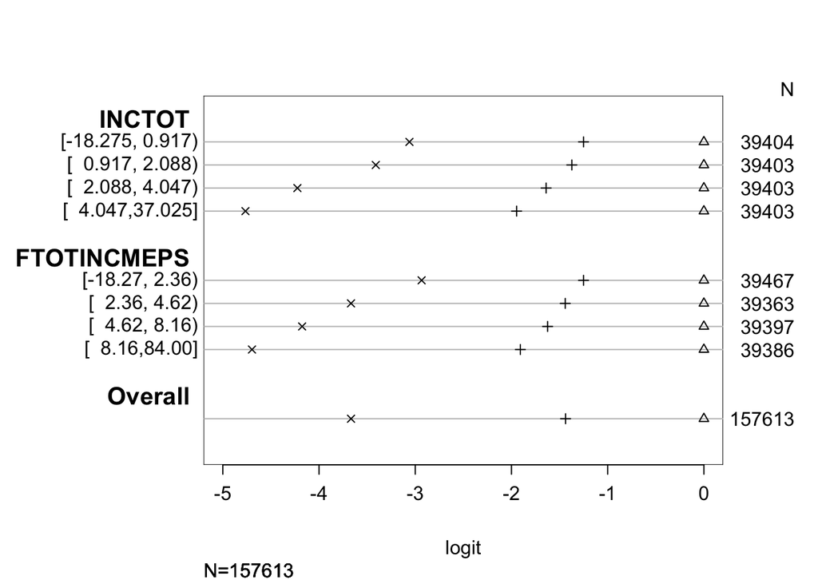

```r
s[, 4] <- s[, 4] - s[, 3]
s[, 3] <- s[, 3] - s[, 3]

 plot.3 <- plot(s, which=1:4, pch=1:4, xlab='logit', main='', xlim=range(-5,0))
```

```r
 #for the most part this is not my code see:  Ordinal Logistic Regression. UCLA: Statistical Consulting Group. from https://stats.oarc.ucla.edu/r/dae/ordinal-logistic-regression/ (accessed August 10, 2023).
```

A more legible way to understand proportional odds. These plots demonstrates how increases in a specific variable (income total) affect probabilities of being placed in each depression(PHQDEP) category.

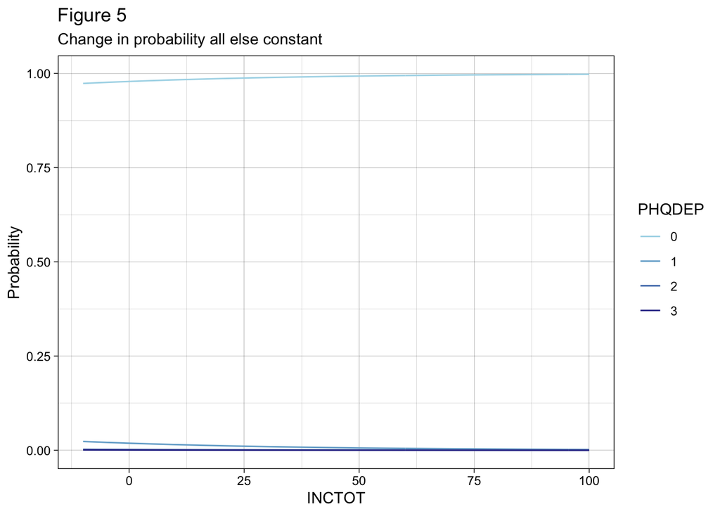

```r
#Creation of a predictions plot

model.predict <- polr(PHQDEP ~ INCTOT + FTOTINCMEPS + REGIONMEPS +SEX + MARSTAT + HEALTH +
                        EDUC + SMOKENOW + RACEA + CANCEREV + INTERVLANG + FAMSIZE + ANERVOUS,data = panel.2,Hess=TRUE)
newdat <- data.frame(
   INCTOT = rep(seq(from = -10, to = 100, length.out = 100),4),
   FTOTINCMEPS = rep(c(46.68)),
   #YEAR = rep(unique(panel$YEAR), length.out = 200),
   REGIONMEPS = rep("3"),
   SEX = rep(c("1")),
   MARSTAT= rep("20"),
   HEALTH = rep("2"),
   EDUC = rep("201"),
   SMOKENOW = rep("1"),
   RACEA = rep("100"),
   CANCEREV = rep("1"),
   INTERVLANG = rep("1"),
   FAMSIZE = rep(2),
   ANERVOUS = rep("0")
)
newdat <- cbind(newdat, predict(model.predict,newdat,type = "probs"))
lnewdat <- melt(newdat, id.vars = c("INCTOT","FTOTINCMEPS","REGIONMEPS","SEX","MARSTAT","HEALTH","EDUC",
                                    "SMOKENOW","RACEA","CANCEREV","INTERVLANG","FAMSIZE","ANERVOUS"),
                variable.name = "PHQDEP",value.name = "Probability")
ggplot(lnewdat, aes(x= INCTOT,y = Probability,color = PHQDEP))+
  labs(title = "Figure 5",subtitle = "Change in probability all else constant ")+
  geom_line()+
  theme_linedraw()+
  scale_color_manual(values = brewer.pal(11, "RdYlBu")[c(8,9,10,11)])
```

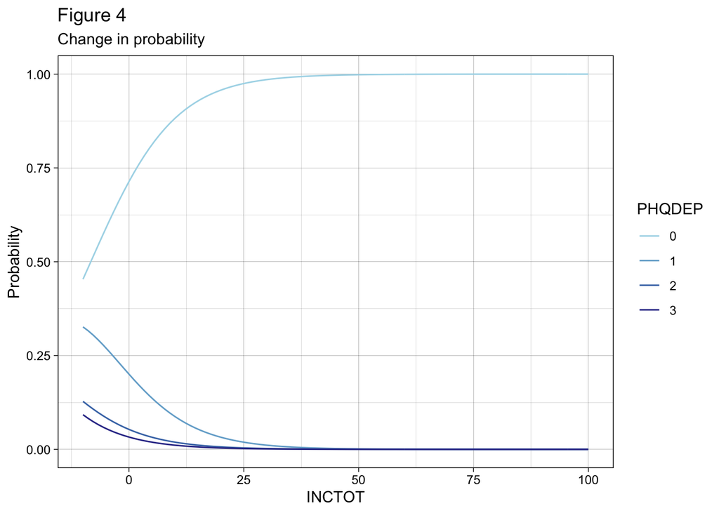

```r
model.predict1 <- polr(PHQDEP ~ INCTOT, data = panel.2, Hess = TRUE)
newdata.1 <- data.frame(
  INCTOT = rep(seq(from = -10, to = 100, length.out = 100),4)
)
newdata.1 <- cbind(newdata.1, predict(model.predict1, newdata.1,type ="probs"))
lnewdat <- melt(newdata.1, id.vars = "INCTOT",variable.name = "PHQDEP",value.name = "Probability")
ggplot(lnewdat, aes(x= INCTOT,y = Probability, color = PHQDEP))+
  labs(title = "Figure 4",subtitle = "Change in probability") +
  geom_line()+
  theme_linedraw()+
  scale_color_manual(values = brewer.pal(11, "RdYlBu")[c(8,9,10,11)])
```

```r
end_time = Sys.time()

print(end_time - start_time)
```

```
## Time difference of 20.15995 mins
```

```r
 #again, for the most part this is not my code see:  Ordinal Logistic Regression. UCLA: Statistical Consulting Group. from https://stats.oarc.ucla.edu/r/dae/ordinal-logistic-regression/ (accessed August 10, 2023).
```

This is a very brief overview of this analysis, for a more thorough investigation, see my paper.